# Chapter 9 Metabarcoding selected filtering based on beta diversity (t4_p0)

```r
load("resources/metagenomics/data_filtered.Rdata")
load("resources/amplicon/selected_filtering_beta.Rdata")
species_color <- c("#e5bd5b", "#6b7398", "#76b183")
```

**Number of MAGs**

```r
genome_metadata_amplicon %>%
  nrow()%>%
  cat()
```

```
79
```

**Number of Archaea phyla**

```r
genome_metadata_amplicon %>%
  filter(domain == "Archaea")%>%
  dplyr::select(phylum) %>%
  unique() %>%
  pull() %>%
  length()%>%
  cat()
```

```
1
```

**Number of Bacteria phyla**

```r
genome_metadata_amplicon %>%
  filter(domain == "Bacteria")%>%
  dplyr::select(phylum) %>%
  unique() %>%
  pull() %>%
  length()%>%
  cat()
```

```
10
```

## 9.1 Taxonomy

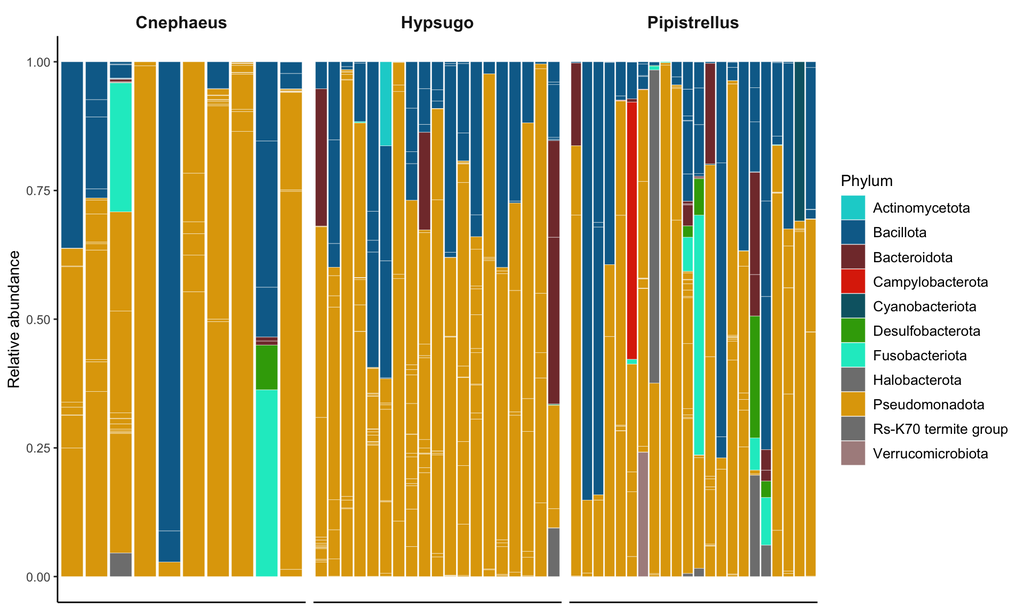

```r
genome_counts_filt_amplicon %>%
  mutate_at(vars(-genome),  ~ . / sum(.)) %>%
  pivot_longer(-genome, names_to = "sample", values_to = "count") %>%
  left_join(., genome_metadata_amplicon, by = join_by(genome == genome)) %>%
  left_join(., sample_metadata_amplicon, by = join_by(sample == sample)) %>%
  filter(count > 0) %>% #filter 0 counts
  ggplot(., aes(
    x = sample,
    y = count,
    fill = phylum,
    group = phylum
  )) +
  geom_bar(stat = "identity",
           colour = "white",
           linewidth = 0.1) +
  scale_fill_manual(values = phylum_colors) +
  facet_nested( ~ factor(
    Species,
    labels = c("Eb" = "Cnephaeus", "Ha" = "Hypsugo", "Pk" = "Pipistrellus")
  ), scales = "free") +
  guides(fill = guide_legend(ncol = 1)) +
  theme(
    axis.text.x = element_blank(),
    axis.ticks.x = element_blank(),
    axis.title.x = element_blank(),
    panel.background = element_blank(),
    panel.border = element_blank(),
    panel.grid.major = element_blank(),
    panel.grid.minor = element_blank(),
    legend.text = element_text(size = 10),
    strip.background = element_rect(fill = "white"),
    strip.text = element_text(
      size = 12,
      lineheight = 0.6,
      face = "bold"
    ),
    axis.line = element_line(
      linewidth = 0.5,
      linetype = "solid",
      colour = "black"
    )
  ) +
  labs(fill = "Phylum", y = "Relative abundance", x = "Samples")+
  guides(fill = guide_legend(ncol = 1))
```

**Grouping low-abundance bacteria**

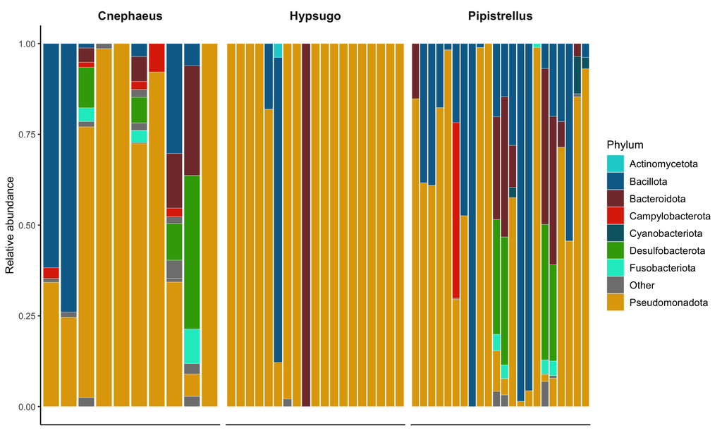

```r
p1 <- genome_counts_filt %>%
  mutate_at(vars(-genome), ~ . / sum(.)) %>%
  pivot_longer(-genome, names_to = "sample", values_to = "count") %>%
  left_join(genome_metadata, by = join_by(genome == genome)) %>%
  left_join(sample_metadata, by = join_by(sample == sample)) %>%
  filter(count > 0) %>%
group_by(sample, phylum) %>%
  mutate(total_abundance = sum(count)) %>%
  ungroup() %>%
  mutate(phylum = if_else(total_abundance < 0.01, "Other", phylum)) %>%
  group_by(sample, phylum, Species) %>%
  summarise(count = sum(count), .groups = "drop") %>%
   ggplot(aes(
    x = sample,
    y = count,
    fill = phylum,
    group = phylum
  )) +
  geom_bar(stat = "identity",
           colour = "white",
           linewidth = 0.1) +
  scale_fill_manual(values = c(phylum_colors, "Other" = "grey50"),
                    drop = FALSE)+
  facet_nested(~ factor(
    Species,
    labels = c("Eb" = "Cnephaeus", "Ha" = "Hypsugo", "Pk" = "Pipistrellus")
  ), scales = "free") +
  guides(fill = guide_legend(ncol = 1)) +
  theme(
    axis.text.x = element_blank(),
    axis.ticks.x = element_blank(),
    axis.title.x = element_blank(),
    panel.background = element_blank(),
    panel.border = element_blank(),
    panel.grid.major = element_blank(),
    panel.grid.minor = element_blank(),
    legend.text = element_text(size = 10),
    strip.background = element_rect(fill = "white"),
    strip.text = element_text(
      size = 12,
      lineheight = 0.6,
      face = "bold"
    ),
    axis.line = element_line(
      linewidth = 0.5,
      linetype = "solid",
      colour = "black"
    )
  ) +
  labs(fill = "Phylum", y = "Relative abundance", x = "Samples")+
  guides(fill = guide_legend(ncol = 1))

#ggsave("community_plot_grouped_selected.pdf", plot = p1, width = 12, height = 6)
p1
```

**Phylum relative abundances**

```r
phylum_summary <- genome_counts_filt_amplicon %>%
  mutate_at(vars(-genome),~./sum(.)) %>%
  pivot_longer(-genome, names_to = "sample", values_to = "count") %>%
  left_join(sample_metadata_amplicon, by = join_by(sample == sample)) %>%
  left_join(genome_metadata_amplicon, by = join_by(genome == genome)) %>%
  group_by(sample,phylum,Species) %>%
  summarise(relabun=sum(count))
```

```r
phylum_summary %>%
  group_by(phylum) %>%
  summarise(
    Total_mean = mean(relabun * 100, na.rm = T),
    Total_sd = sd(relabun * 100, na.rm = T),
    Eb_mean = mean(relabun[Species == "Eb"] * 100, na.rm = T),
    Eb_sd = sd(relabun[Species == "Eb"] * 100, na.rm = T),
    Ha_mean = mean(relabun[Species == "Ha"] * 100, na.rm = T),
    Ha_sd = sd(relabun[Species == "Ha"] * 100, na.rm = T),
    Pk_mean = mean(relabun[Species == "Pk"] * 100, na.rm = T),
    Pk_sd = sd(relabun[Species == "Pk"] * 100, na.rm = T)
  ) %>%
  mutate(
    Total = str_c(round(Total_mean, 3), "±", round(Total_sd, 3)),
    Cnephaeus = str_c(round(Eb_mean, 3), "±", round(Eb_sd, 3)),
    Hypsugo = str_c(round(Ha_mean, 3), "±", round(Ha_sd, 3)),
    Pipistrellus = str_c(round(Pk_mean, 3), "±", round(Pk_sd, 3))
  ) %>%
  arrange(-Total_mean) %>%
  dplyr::select(phylum,
                Total,
                Cnephaeus,
                Hypsugo,
                Pipistrellus) %>%
  tt()
```

| phylum | Total | Cnephaeus | Hypsugo | Pipistrellus |
| --- | --- | --- | --- | --- |
| Pseudomonadota | 65.046±30.493 | 69.57±38.576 | 72.4±22.037 | 56.639±32.048 |
| Bacillota | 23.641±25.626 | 22.74±31.991 | 21.12±17.56 | 26.227±29.111 |
| Bacteroidota | 3.421±9.565 | 0.219±0.514 | 5.097±13.327 | 3.429±7.62 |
| Fusobacteriota | 2.601±8.882 | 6.14±13.202 | 0.015±0.062 | 3.227±10.035 |
| Halobacterota | 1.193±8.517 | 0±0 | 0±0 | 2.765±12.968 |
| Campylobacterota | 0.983±6.993 | 0±0 | 0±0 | 2.279±10.646 |
| Desulfobacterota | 0.886±3.639 | 0.875±2.742 | 0.009±0.041 | 1.649±5.196 |
| Rs-K70 termite group | 0.823±3.169 | 0.457±1.446 | 0.496±2.16 | 1.271±4.318 |
| Cyanobacteriota | 0.613±4.33 | 0±0 | 0.005±0.023 | 1.417±6.592 |
| Verrucomicrobiota | 0.473±3.38 | 0±0 | 0±0 | 1.097±5.146 |
| Actinomycetota | 0.32±2.284 | 0±0 | 0.859±3.742 | 0±0 |

```r
bats = c("Eb", "Pk", "Ha")

total_asvs <- data.frame(
  Bat = character(),
  ASVs = numeric(),
  Phylum = numeric(),
  Family = numeric(),
  Genus = numeric()
)

preabs_table <- genome_counts_filt_amplicon %>%
  mutate(across(-genome, ~ . / sum(.))) %>%
  column_to_rownames("genome") %>%
  mutate(across(everything(), ~ as.integer(. > 0))) %>%
  t() %>%
  as.data.frame() %>%
  rownames_to_column("sample") %>%
  left_join(sample_metadata_amplicon[c("sample", "Species")], by = "sample") %>%
  group_by(Species) %>%
  summarize(across(-sample, sum), .groups = "drop") %>%
  column_to_rownames("Species") %>%
  t() %>%
  as.data.frame() %>%
  rownames_to_column("genome")  %>%
  left_join(genome_metadata_amplicon, by = join_by("genome" == "genome"))
# %>%
#   filter(domain=="Bacteria")

phylum <- preabs_table %>%
  distinct(phylum)

family <- preabs_table %>%
  distinct(phylum, class, order, family)

genus <- preabs_table %>%
  distinct(phylum, class, order, family, genus)

total_asvs <- rbind(
  total_asvs,
  data.frame(
    Bat = "Total",
    ASVs = nrow(preabs_table),
    Phylum = nrow(phylum),
    Family = nrow(family),
    Genus = nrow(genus)
  )
)

for (bat in bats) {
  number <- preabs_table %>%
    select({{bat}}) %>%
    filter(. >= 1)

  phylum <- preabs_table %>%
    select({{bat}}, phylum) %>%
    filter(!!sym(bat) >= 1) %>%
    distinct(phylum)

  family <- preabs_table %>%
    select({{bat}}, phylum, class, order, family) %>%
    filter(!!sym(bat) >= 1) %>%
    distinct(phylum, class, order, family)

  genus <- preabs_table %>%
    select({{bat}}, phylum, class, order, family, genus) %>%
    filter(!!sym(bat) >= 1) %>%
    distinct(phylum, class, order, family, genus)

  total_asvs <- rbind(
    total_asvs,
    data.frame(
      Bat = bat,
      ASVs = nrow(number),
      Phylum = nrow(phylum),
      Family = nrow(family),
      Genus = nrow(genus)
    )
  )
}
```

```r
bats = c("Eb", "Pk", "Ha")

no_annotation <- data.frame(Bat = character(),
                            No_genus = numeric(),
                            No_species = numeric())

preabs_table <- genome_counts_filt_amplicon %>%
  mutate(across(-genome, ~ . / sum(.))) %>%
  column_to_rownames("genome") %>%
  mutate(across(everything(), ~ as.integer(. > 0))) %>%
  t() %>%
  as.data.frame() %>%
  rownames_to_column("sample") %>%
  left_join(sample_metadata_amplicon[c("sample", "Species")], by = "sample") %>%
  group_by(Species) %>%
  summarize(across(-sample, sum), .groups = "drop") %>%
  column_to_rownames("Species") %>%
  t() %>%
  as.data.frame() %>%
  rownames_to_column("genome")  %>%
  left_join(genome_metadata_amplicon, by = join_by("genome" == "genome"))
# %>%
#   filter(domain=="Bacteria")

genus <- preabs_table  %>%
  filter(is.na(genus))

species <- preabs_table  %>%
  filter(is.na(species))

no_annotation <- rbind(no_annotation,
                       data.frame(
                         Bat = "Total",
                         No_genus = nrow(genus),
                         No_species = nrow(species)
                       ))

for (bat in bats) {
  number <- preabs_table %>%
    select({{bat}}) %>%
    filter(. >= 1)

  genus <- preabs_table %>%
    select({{bat}}, phylum, class, order, family, genus) %>%
    filter(!!sym(bat) >= 1) %>%
  filter(is.na(genus))

  species <- preabs_table %>%
    filter(!!sym(bat) >= 1) %>%
  filter(is.na(species))

  no_annotation <- rbind(no_annotation,
                         data.frame(
                           Bat = bat,
                           No_genus = nrow(genus),
                           No_species = nrow(species)
                         ))
}
```

**Total percentage of ASVs without genus-level annotation**

```r
nongenera <- genome_metadata_amplicon %>%
  filter(domain=="Bacteria") %>%
  filter(is.na(genus)) %>%
  summarize(ASV_nogenera = n()) %>%
  pull()
nasvs <- total_asvs %>%
  filter(Bat == "Total") %>%
  select(ASVs) %>%
  pull()
perct <- nongenera * 100 / nasvs
cat(perct)
```

```
15.18987
```

**Percentage of ASVs without genus-level annotation by phylum**

```r
total_asv_phylum <- genome_metadata_amplicon %>%
  filter(domain=="Bacteria") %>%
  group_by(phylum) %>%
  summarize(Total_ASVs = n())
genome_metadata_amplicon %>%
  filter(is.na(genus)) %>%
  group_by(phylum) %>%
  summarize(ASVs_nogenus = n()) %>%
  left_join(total_asv_phylum, by = join_by(phylum == phylum)) %>%
  mutate(Percentage_nogenus = 100 * ASVs_nogenus / Total_ASVs) %>%
  tt()
```

| phylum | ASVs_nogenus | Total_ASVs | Percentage_nogenus |
| --- | --- | --- | --- |
| Pseudomonadota | 11 | 50 | 22 |
| Rs-K70 termite group | 1 | 1 | 100 |

**Number of bacterial species**

```r
genome_metadata_amplicon %>%
  filter(domain == "Bacteria")%>%
  dplyr::select(species) %>%
  unique() %>%
  drop_na() %>%
  pull() %>%
  length() %>%
  cat()
```

```
10
```

**Total percentage of ASVs without species-level annotation**

```r
nonspecies <- genome_metadata_amplicon %>%
  filter(domain=="Bacteria") %>%
  filter(is.na(species)) %>%
  summarize(ASV_nospecies = n()) %>%
  pull()
perct <- nonspecies * 100 / nasvs
cat(perct)
```

```
83.5443
```

**ASVs without species-level annotation**

```r
total_mag_phylum <- genome_metadata_amplicon %>%
  filter(domain=="Bacteria") %>%
  group_by(phylum) %>%
  summarize(ASVs_total = n())

genome_metadata_amplicon %>%
  filter(domain=="Bacteria") %>%
  filter(is.na(species)) %>%
  group_by(phylum) %>%
  summarize(ASVs_nospecies = n()) %>%
  left_join(total_mag_phylum, by = join_by(phylum == phylum)) %>%
  mutate(Species_annotated = ASVs_total - ASVs_nospecies) %>%
  mutate(Percentage_nospecies = 100 * ASVs_nospecies / ASVs_total) %>%
  mutate(Percentage_species = 100 - 100 * ASVs_nospecies / ASVs_total) %>%
  tt()
```

| phylum | ASVs_nospecies | ASVs_total | Species_annotated | Percentage_nospecies | Percentage_species |
| --- | --- | --- | --- | --- | --- |
| Actinomycetota | 1 | 1 | 0 | 100.00000 | 0.000000 |
| Bacillota | 14 | 15 | 1 | 93.33333 | 6.666667 |
| Bacteroidota | 5 | 6 | 1 | 83.33333 | 16.666667 |
| Campylobacterota | 1 | 1 | 0 | 100.00000 | 0.000000 |
| Cyanobacteriota | 1 | 1 | 0 | 100.00000 | 0.000000 |
| Desulfobacterota | 1 | 1 | 0 | 100.00000 | 0.000000 |
| Pseudomonadota | 41 | 50 | 9 | 82.00000 | 18.000000 |
| Rs-K70 termite group | 1 | 1 | 0 | 100.00000 | 0.000000 |
| Verrucomicrobiota | 1 | 1 | 0 | 100.00000 | 0.000000 |

### 9.1.1 Summary table

```r
bats = c("Eb", "Pk", "Ha")

single_sp <- data.frame(Bat = character(), Single_species = numeric())

# bacteria <- genome_metadata_amplicon %>%
#   filter(domain=="Bacteria")

table_upset_analysis <- genome_counts_filt_amplicon %>%
  mutate(across(-genome, ~ . / sum(.))) %>%
#  filter(genome %in% bacteria$genome) %>%
  column_to_rownames("genome") %>%
  mutate(across(everything(), ~ as.integer(. > 0))) %>%
  t() %>%
  as.data.frame() %>%
  rownames_to_column("sample") %>%
  left_join(sample_metadata_amplicon[c("sample", "Species")], by = "sample") %>%
  group_by(Species) %>%
  summarize(across(-sample, sum), .groups = "drop") %>%
  column_to_rownames("Species") %>%
  mutate(across(everything(), ~ as.integer(. > 0))) %>%
  t() %>%
  as.data.frame() %>%
  rownames_to_column("sample")

unique_all <- table_upset_analysis %>%
  filter(rowSums(across(Eb:Pk)) == 1)

single_sp <- rbind(single_sp, data.frame(Bat = "Total",
                                         Single_species = nrow(unique_all)))

for (bat in bats) {
  unique <- table_upset_analysis %>%
    filter(rowSums(across(Eb:Pk)) == 1) %>%
    column_to_rownames(., "sample") %>%
    select(bat) %>%
    filter(. > 0) %>%
    nrow()
  single_sp <- rbind(single_sp, data.frame(Bat = bat, Single_species = unique))
}
```

```r
single_ind <- data.frame(Bat = character(), Single_individual = numeric())

freq_table <- genome_counts_filt_amplicon %>%
  mutate(across(-genome, ~ . / sum(.))) %>%
#  filter(genome %in% bacteria$genome) %>%
  column_to_rownames("genome") %>%
  mutate(across(everything(), ~ as.integer(. > 0))) %>%
  t() %>%
  as.data.frame() %>%
  rownames_to_column("sample") %>%
  left_join(sample_metadata_amplicon[c("sample", "Species")], by = "sample") %>%
  group_by(Species) %>%
  summarize(across(-sample, sum), .groups = "drop") %>%
  column_to_rownames("Species") %>%
  t() %>%
  as.data.frame() %>%
  rownames_to_column("asv")

singleton_filt <- freq_table %>%
  rowwise() %>%
  mutate(row_sum = sum(c_across(-asv))) %>%
  filter(row_sum == 1) %>%
  column_to_rownames(var = "asv")  %>%
  filter(row_sum == 1)

single_ind <- rbind(single_ind, data.frame(
  Bat = "Total",
  Single_individual = nrow(singleton_filt)
))

for (bat in bats) {
  singleton_filt <- freq_table %>%
    rowwise() %>%
    mutate(row_sum = sum(c_across(-asv))) %>%
    filter(row_sum == 1) %>%
    column_to_rownames(var = "asv")  %>%
    select(bat) %>%
    filter(. == 1)

  single_ind <- rbind(single_ind, data.frame(
    Bat = bat,
    Single_individual = nrow(singleton_filt)
  ))
}
```

```r
summary_table_ampli <- total_asvs %>%
  left_join(., no_annotation, by = "Bat") %>%
  left_join(., single_ind, by = "Bat") %>%
  left_join(., single_sp, by = "Bat") %>%
  mutate(Bat = recode(Bat,
                      Eb = "Cnephaeus bottae",
                      Ha = "Hypsugo ariel",
                      Pk = "Pipistrellus kuhlii"))
summary_table_ampli %>%
  tt()
```

| Bat | ASVs | Phylum | Family | Genus | No_genus | No_species | Single_individual | Single_species |
| --- | --- | --- | --- | --- | --- | --- | --- | --- |
| Total | 79 | 11 | 36 | 50 | 12 | 67 | 13 | 25 |
| Cnephaeus bottae | 43 | 6 | 22 | 29 | 5 | 37 | 1 | 2 |
| Pipistrellus kuhlii | 62 | 10 | 30 | 40 | 9 | 56 | 5 | 10 |
| Hypsugo ariel | 62 | 8 | 31 | 41 | 10 | 55 | 7 | 13 |

```r
total_asv <- nrow(genome_metadata_amplicon)
summary_table_ampli %>%
  select(-Phylum,-Family, -Genus) %>%
  rowwise() %>%
  mutate(ASV_perc=round(ASVs*100/total_asv, 2))%>%
  mutate(No_genus_perc=round(No_genus*100/ASVs, 2))%>%
  mutate(No_species_perc=round(No_species*100/ASVs, 2)) %>%
  mutate(Single_individual_perc=round(Single_individual*100/ASVs, 2))%>%
  mutate(Single_species_perc=round(Single_species*100/ASVs, 2)) %>%
  mutate(Single_individual_per_unique=round(Single_individual*100/Single_species, 2)) %>%
  select(1,7:12) %>% tt()
```

| Bat | ASV_perc | No_genus_perc | No_species_perc | Single_individual_perc | Single_species_perc | Single_individual_per_unique |
| --- | --- | --- | --- | --- | --- | --- |
| Total | 100.00 | 15.19 | 84.81 | 16.46 | 31.65 | 52.00 |
| Cnephaeus bottae | 54.43 | 11.63 | 86.05 | 2.33 | 4.65 | 50.00 |
| Pipistrellus kuhlii | 78.48 | 14.52 | 90.32 | 8.06 | 16.13 | 50.00 |
| Hypsugo ariel | 78.48 | 16.13 | 88.71 | 11.29 | 20.97 | 53.85 |

**Shared phyla**

```r
meta_phylum <- genome_metadata %>%
  distinct(domain,phylum)

genome_metadata_amplicon %>%
  distinct(domain,phylum) %>%
  filter(phylum %in% meta_phylum$phylum)
```

```
    domain           phylum
1 Bacteria   Pseudomonadota
2 Bacteria   Fusobacteriota
3 Bacteria        Bacillota
4 Bacteria Desulfobacterota
5 Bacteria     Bacteroidota
6 Bacteria  Cyanobacteriota
7 Bacteria Campylobacterota
8 Bacteria   Actinomycetota
```

**Only in metagenomic data**

```r
ampli_phylum <- genome_metadata_amplicon %>%
  distinct(domain,phylum)

genome_metadata %>%
  distinct(domain,phylum) %>%
  filter(!phylum %in% genome_metadata_amplicon$phylum)
```

```
# A tibble: 5 × 2
  domain   phylum
  <chr>    <chr>
1 Bacteria Elusimicrobiota
2 Bacteria Deferribacterota
3 Bacteria Planctomycetota
4 Bacteria Spirochaetota
5 Bacteria Synergistota
```

**Only in metabarcoding selected data**

```r
genome_metadata_amplicon %>%
  distinct(domain,phylum) %>%
  filter(!phylum %in% meta_phylum$phylum)
```

```
    domain               phylum
1 Bacteria Rs-K70 termite group
2  Archaea        Halobacterota
3 Bacteria    Verrucomicrobiota
```

### 9.1.2 Differences at family level

**Number of families in metagenomic data**

```r
load("resources/metagenomics/data_filtered.Rdata")
```

```r
cat(genome_metadata %>%
      distinct(domain, phylum, family) %>%
      count() %>%
      pull())
```

```
56
```

**Number of families in metabarcoding selected data**

```r
cat(genome_metadata_amplicon %>%
      distinct(domain, phylum, family) %>%
      count() %>%
      pull())
```

```
36
```

**Shared families**

```r
meta_family <- genome_metadata %>%
  distinct(domain,phylum, family)

genome_metadata_amplicon %>%
  distinct(domain,phylum, family) %>%
  filter(family %in% meta_family$family)
```

```
     domain           phylum              family
1  Bacteria   Pseudomonadota Diplorickettsiaceae
2  Bacteria   Pseudomonadota        Vibrionaceae
3  Bacteria   Pseudomonadota  Enterobacteriaceae
4  Bacteria   Fusobacteriota    Leptotrichiaceae
5  Bacteria        Bacillota     Enterococcaceae
6  Bacteria   Pseudomonadota      Morganellaceae
7  Bacteria   Pseudomonadota     Pasteurellaceae
8  Bacteria   Pseudomonadota      Aeromonadaceae
9  Bacteria        Bacillota    Mycoplasmataceae
10 Bacteria        Bacillota    Streptococcaceae
11 Bacteria   Pseudomonadota      Rickettsiaceae
12 Bacteria   Pseudomonadota        Rhizobiaceae
13 Bacteria Desulfobacterota Desulfovibrionaceae
14 Bacteria     Bacteroidota   Dysgonomonadaceae
15 Bacteria        Bacillota     Lachnospiraceae
16 Bacteria   Pseudomonadota    Burkholderiaceae
17 Bacteria Campylobacterota   Helicobacteraceae
18 Bacteria   Actinomycetota      Micrococcaceae
19 Bacteria        Bacillota      Clostridiaceae
20 Bacteria     Bacteroidota       Weeksellaceae
21 Bacteria   Pseudomonadota    Acetobacteraceae
22 Bacteria   Pseudomonadota      Halomonadaceae
23 Bacteria   Pseudomonadota       Neisseriaceae
```

**Only in metagenomic data**

```r
ampli_family <- genome_metadata_amplicon %>%
  distinct(domain,phylum,family)

genome_metadata %>%
  distinct(domain,phylum,family) %>%
  filter(!family %in% ampli_family$family)
```

```
# A tibble: 33 × 3
   domain   phylum           family
   <chr>    <chr>            <chr>
 1 Bacteria Pseudomonadota   ""
 2 Bacteria Bacteroidota     "Bacteroidaceae"
 3 Bacteria Campylobacterota "Campylobacteraceae"
 4 Bacteria Pseudomonadota   "Rhodocyclaceae"
 5 Bacteria Bacillota        "Erysipelotrichaceae"
 6 Bacteria Elusimicrobiota  "Elusimicrobiaceae"
 7 Bacteria Bacillota        "Metamycoplasmataceae"
 8 Bacteria Bacillota        "Acutalibacteraceae"
 9 Bacteria Pseudomonadota   "CAG-239"
10 Bacteria Bacillota        ""
# ℹ 23 more rows
```

**Only in metabarcoding selected data**

```r
genome_metadata_amplicon %>%
  distinct(domain,phylum,family) %>%
  filter(!family %in% meta_family$family)
```

```
     domain               phylum             family
1  Bacteria       Pseudomonadota       Yersiniaceae
2  Bacteria            Bacillota        Bacillaceae
3  Bacteria Rs-K70 termite group               <NA>
4  Bacteria            Bacillota Entomoplasmataceae
5  Bacteria      Cyanobacteriota     Microcystaceae
6  Bacteria       Pseudomonadota   Pseudomonadaceae
7  Bacteria       Pseudomonadota               <NA>
8   Archaea        Halobacterota Methanosarcinaceae
9  Bacteria       Pseudomonadota   Oxalobacteraceae
10 Bacteria       Pseudomonadota        Erwiniaceae
11 Bacteria            Bacillota   Lactobacillaceae
12 Bacteria    Verrucomicrobiota       Simkaniaceae
13 Bacteria       Pseudomonadota           Orbaceae
```

## 9.2 Alpha Diversity

### 9.2.1 ASV level

```r
richness <- genome_counts_filt_amplicon %>%
  column_to_rownames(var = "genome") %>%
  dplyr::select(where( ~ !all(. == 0))) %>%
  hilldiv(., q = 0) %>%
  t() %>%
  as.data.frame() %>%
  dplyr::rename(richness = 1) %>%
  rownames_to_column(var = "sample")

neutral <- genome_counts_filt_amplicon %>%
  column_to_rownames(var = "genome") %>%
  dplyr::select(where( ~ !all(. == 0))) %>%
  hilldiv(., q = 1) %>%
  t() %>%
  as.data.frame() %>%
  dplyr::rename(neutral = 1) %>%
  rownames_to_column(var = "sample")

metabarcoding_selected_alpha_div <- richness %>%
  full_join(neutral, by = join_by(sample == sample)) %>%
  mutate(method="Metabarcoding_selected_beta")
```

**Correlation between diversity and estimate microbial fraction**

```r
fraction_ampli <- microbial_fraction %>%
  select(sample, estimated_microbial_fraction) %>%
  right_join(metabarcoding_selected_alpha_div, by="sample") %>%
  left_join(sample_metadata_amplicon, by="sample")

cor.test(fraction_ampli$estimated_microbial_fraction, fraction_ampli$richness, method = "spearman")
```

```
    Spearman's rank correlation rho

data:  fraction_ampli$estimated_microbial_fraction and fraction_ampli$richness
S = 20749, p-value = 0.05981
alternative hypothesis: true rho is not equal to 0
sample estimates:
       rho
-0.2796438
```

```r
cor.test(fraction_ampli$estimated_microbial_fraction, fraction_ampli$neutral, method = "spearman")
```

```
    Spearman's rank correlation rho

data:  fraction_ampli$estimated_microbial_fraction and fraction_ampli$neutral
S = 22184, p-value = 0.01226
alternative hypothesis: true rho is not equal to 0
sample estimates:
       rho
-0.3681159
```

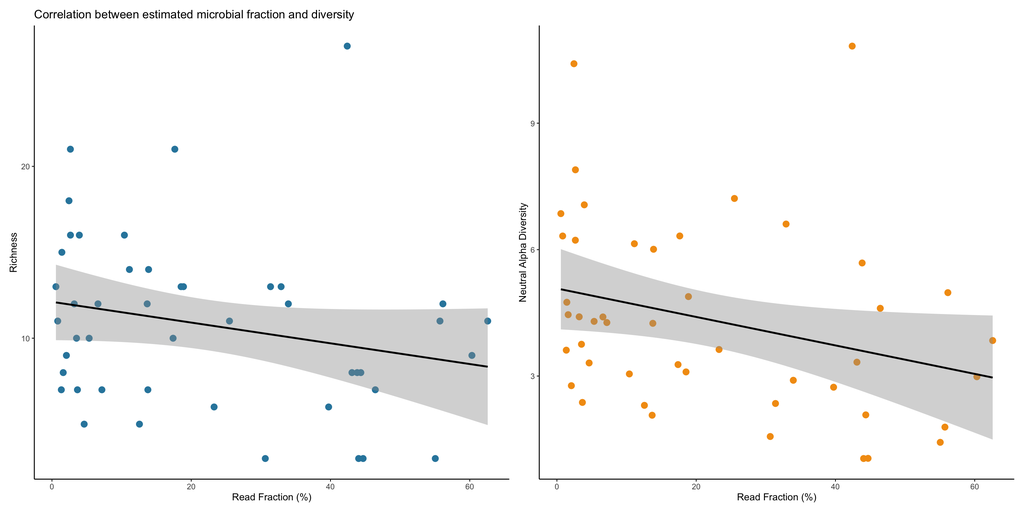

```r
p1_ampli <- ggplot(fraction_ampli, aes(x = estimated_microbial_fraction, y = richness)) +
  geom_point(size = 3, color = "#2E86AB") +
  geom_smooth(method = "lm", se = TRUE, color = "black") +
  theme_classic() +
  labs(x = "Read Fraction (%)", y = "Richness", title= "Correlation between estimated microbial fraction and diversity")

p2_ampli <- ggplot(fraction_ampli, aes(x = estimated_microbial_fraction, y = neutral)) +
  geom_point(size = 3, color = "#F39C12") +
  geom_smooth(method = "lm", se = TRUE, color = "black") +
  theme_classic() +
  labs(x = "Read Fraction (%)", y = "Neutral Alpha Diversity")

p1_ampli + p2_ampli
```

```r
richness %>%
  full_join(neutral, by = join_by(sample == sample))  %>%
  pivot_longer(-sample, names_to = "alpha", values_to = "value") %>%
  left_join(sample_metadata, by = join_by(sample == sample)) %>%
  group_by(alpha) %>%
  summarise(
    total_mean = mean(value, na.rm = T),
    total_sd = sd(value, na.rm = T),
    Eb_mean = mean(value[Species == "Eb"], na.rm = T),
    Eb_sd = sd(value[Species == "Eb"], na.rm = T),
    Ha_mean = mean(value[Species == "Ha"], na.rm = T),
    Ha_sd = sd(value[Species == "Ha"], na.rm = T),
    Pk_mean = mean(value[Species == "Pk"], na.rm = T),
    Pk_sd = sd(value[Species == "Pk"], na.rm = T)
  ) %>%
  mutate(
    Total = str_c(round(total_mean, 2), "±", round(total_sd, 2)),
    Cnephaeus = str_c(round(Eb_mean, 2), "±", round(Eb_sd, 2)),
    Hypsugo = str_c(round(Ha_mean, 2), "±", round(Ha_sd, 2)),
    Pipistrellus = str_c(round(Pk_mean, 2), "±", round(Pk_sd, 2))
  ) %>%
  arrange(-Eb_mean) %>%
  dplyr::select(alpha, Total, Cnephaeus, Pipistrellus, Hypsugo) %>%
  tt()
```

| alpha | Total | Cnephaeus | Pipistrellus | Hypsugo |
| --- | --- | --- | --- | --- |
| richness | 10.61±4.95 | 10.1±5.49 | 9.55±5.29 | 12.11±4.07 |
| neutral | 4.24±2.16 | 3.51±1.96 | 3.89±2.15 | 5.03±2.14 |

### 9.2.2 Different taxonomic level

```r
sample_metadata_amplicon <- sample_metadata_amplicon[c(1,9,10,13)] %>%
  mutate(sample = paste0(sample, "_ampli_selec")) %>%
  mutate(method="Metabarcoding_selected_beta")

genome_metadata_amplicon <- genome_metadata_amplicon %>%
  mutate(
    class  = if_else(is.na(class), paste0(phylum, "_Unclassified"), class),
    order  = if_else(is.na(order),
                     if_else(str_detect(class, "Unclassified"), class, paste0(class, "_Unclassified")),
                     order),
    family = if_else(is.na(family),
                     if_else(str_detect(order, "Unclassified"), order, paste0(order, "_Unclassified")),
                     family),
    genus  = if_else(is.na(genus),
                     if_else(str_detect(family, "Unclassified"), family, paste0(family, "_Unclassified")),
                     genus)
  )

genome_tax_ampli <- genome_counts_filt_amplicon %>%
  column_to_rownames(., "genome")%>%
  rename_with(~ paste0(., "_ampli_selec")) %>%
  rownames_to_column(., "genome")%>%
  left_join(genome_metadata_amplicon, by = "genome")

family_level_agg_ampli <- genome_tax_ampli %>%
  select(-genome) %>%
  group_by(phylum, class, family) %>%
  summarise(across(where(is.numeric), \(x) sum(x, na.rm = TRUE)), .groups = "drop")%>%
    as.data.frame() %>%
  select(-c(phylum,class))

phylum_level_agg_ampli <- genome_tax_ampli %>%
  select(-genome) %>%
  group_by(phylum) %>%
  summarise(across(where(is.numeric), \(x) sum(x, na.rm = TRUE)), .groups = "drop")%>%
    as.data.frame()
```

#### 9.2.2.1 Family level

```r
richness_f_ampli <- family_level_agg_ampli %>%
  column_to_rownames(var = "family") %>%
  dplyr::select(where( ~ !all(. == 0))) %>%
  hilldiv(., q = 0) %>%
  t() %>%
  as.data.frame() %>%
  dplyr::rename(richness = 1) %>%
  rownames_to_column(var = "sample")

neutral_f_ampli <- family_level_agg_ampli %>%
  column_to_rownames(var = "family") %>%
  dplyr::select(where( ~ !all(. == 0))) %>%
  hilldiv(., q = 1) %>%
  t() %>%
  as.data.frame() %>%
  dplyr::rename(neutral = 1) %>%
  rownames_to_column(var = "sample")

alpha_div_f_ampli <- richness_f_ampli %>%
  full_join(neutral_f_ampli, by = join_by(sample == sample))

alpha_div_f_ampli_data <- alpha_div_f_ampli %>%
  left_join(sample_metadata_amplicon, by = join_by(sample == sample))
```

**Diversity values**

```r
alpha_div_f_ampli %>%
  pivot_longer(-sample, names_to = "alpha", values_to = "value") %>%
  left_join(sample_metadata_amplicon, by = join_by(sample == sample)) %>%
  group_by(alpha) %>%
  summarise(
    total_mean = mean(value, na.rm = T),
    total_sd = sd(value, na.rm = T),
    Eb_mean = mean(value[Species == "Eb"], na.rm = T),
    Eb_sd = sd(value[Species == "Eb"], na.rm = T),
    Ha_mean = mean(value[Species == "Ha"], na.rm = T),
    Ha_sd = sd(value[Species == "Ha"], na.rm = T),
    Pk_mean = mean(value[Species == "Pk"], na.rm = T),
    Pk_sd = sd(value[Species == "Pk"], na.rm = T)
  ) %>%
  mutate(
    Total = str_c(round(total_mean, 2), "±", round(total_sd, 2)),
    Cnephaeus = str_c(round(Eb_mean, 2), "±", round(Eb_sd, 2)),
    Hypsugo = str_c(round(Ha_mean, 2), "±", round(Ha_sd, 2)),
    Pipistrellus = str_c(round(Pk_mean, 2), "±", round(Pk_sd, 2))
  ) %>%
  arrange(-Eb_mean) %>%
  dplyr::select(alpha, Total, Cnephaeus, Pipistrellus, Hypsugo) %>%
  tt()
```

| alpha | Total | Cnephaeus | Pipistrellus | Hypsugo |
| --- | --- | --- | --- | --- |
| richness | 7.22±3.25 | 5.4±2.76 | 6.95±3.59 | 8.47±2.63 |
| neutral | 3.16±1.5 | 2.25±1.01 | 2.85±1.5 | 4±1.34 |

**Richness**

```r
Model_richness <- MASS::glm.nb(richness ~ Species, data = alpha_div_f_ampli_data,trace=TRUE)
summary(Model_richness)
```

```
Call:
MASS::glm.nb(formula = richness ~ Species, data = alpha_div_f_ampli_data,
    trace = TRUE, init.theta = 30.49122173, link = log)

Coefficients:
            Estimate Std. Error z value Pr(>|z|)
(Intercept)   1.6864     0.1476  11.422  < 2e-16 ***
SpeciesHa     0.4506     0.1724   2.613  0.00898 **
SpeciesPk     0.2530     0.1727   1.465  0.14293
---
Signif. codes:  0 '***' 0.001 '**' 0.01 '*' 0.05 '.' 0.1 ' ' 1

(Dispersion parameter for Negative Binomial(30.4912) family taken to be 1)

    Null deviance: 57.647  on 50  degrees of freedom
Residual deviance: 50.201  on 48  degrees of freedom
AIC: 259.6

Number of Fisher Scoring iterations: 1

              Theta:  30.5
          Std. Err.:  30.8

 2 x log-likelihood:  -251.604
```

```r
anova(Model_richness)
```

```
Analysis of Deviance Table

Model: Negative Binomial(30.4912), link: log

Response: richness

Terms added sequentially (first to last)

        Df Deviance Resid. Df Resid. Dev Pr(>Chi)
NULL                       50     57.647
Species  2   7.4463        48     50.201  0.02416 *
---
Signif. codes:  0 '***' 0.001 '**' 0.01 '*' 0.05 '.' 0.1 ' ' 1
```

```r
emmeans(Model_richness, pairwise ~ Species)
```

```
$emmeans
 Species emmean     SE  df asymp.LCL asymp.UCL
 Eb        1.69 0.1480 Inf      1.40      1.98
 Ha        2.14 0.0891 Inf      1.96      2.31
 Pk        1.94 0.0896 Inf      1.76      2.11

Results are given on the log (not the response) scale.
Confidence level used: 0.95

$contrasts
 contrast estimate    SE  df z.ratio p.value
 Eb - Ha    -0.451 0.172 Inf  -2.613  0.0244
 Eb - Pk    -0.253 0.173 Inf  -1.465  0.3079
 Ha - Pk     0.198 0.126 Inf   1.564  0.2615

Results are given on the log (not the response) scale.
P value adjustment: tukey method for comparing a family of 3 estimates
```

**Neutral**

```r
Model_neutral <- lm(formula = neutral ~ Species, data = alpha_div_f_ampli_data)
anova(Model_neutral)
```

```
Analysis of Variance Table

Response: neutral
          Df Sum Sq Mean Sq F value   Pr(>F)
Species    2 23.811 11.9053  6.4164 0.003392 **
Residuals 48 89.061  1.8554
---
Signif. codes:  0 '***' 0.001 '**' 0.01 '*' 0.05 '.' 0.1 ' ' 1
```

```r
emmeans(Model_neutral, pairwise ~ Species)
```

```
$emmeans
 Species emmean    SE df lower.CL upper.CL
 Eb        2.25 0.431 48     1.38     3.12
 Ha        4.00 0.312 48     3.37     4.63
 Pk        2.85 0.290 48     2.26     3.43

Confidence level used: 0.95

$contrasts
 contrast estimate    SE df t.ratio p.value
 Eb - Ha    -1.748 0.532 48  -3.285  0.0053
 Eb - Pk    -0.595 0.520 48  -1.146  0.4908
 Ha - Pk     1.153 0.427 48   2.702  0.0253

P value adjustment: tukey method for comparing a family of 3 estimates
```

#### 9.2.2.2 Phylum level

```r
richness_p_ampli <- phylum_level_agg_ampli %>%
  column_to_rownames(var = "phylum") %>%
  dplyr::select(where( ~ !all(. == 0))) %>%
  hilldiv(., q = 0) %>%
  t() %>%
  as.data.frame() %>%
  dplyr::rename(richness = 1) %>%
  rownames_to_column(var = "sample")

neutral_p_ampli <- phylum_level_agg_ampli %>%
  column_to_rownames(var = "phylum") %>%
  dplyr::select(where( ~ !all(. == 0))) %>%
  hilldiv(., q = 1) %>%
  t() %>%
  as.data.frame() %>%
  dplyr::rename(neutral = 1) %>%
  rownames_to_column(var = "sample")

alpha_div_phylum_ampli <- richness_p_ampli %>%
  full_join(neutral_p_ampli, by = join_by(sample == sample))

alpha_div_phylum_ampli_data <- alpha_div_phylum_ampli %>%
  left_join(sample_metadata_amplicon, by = join_by(sample == sample))
```

**Diversity values**

```r
alpha_div_phylum_ampli %>%
  pivot_longer(-sample, names_to = "alpha", values_to = "value") %>%
  left_join(sample_metadata_amplicon, by = join_by(sample == sample)) %>%
  group_by(alpha) %>%
  summarise(
    total_mean = mean(value, na.rm = T),
    total_sd = sd(value, na.rm = T),
    Eb_mean = mean(value[Species == "Eb"], na.rm = T),
    Eb_sd = sd(value[Species == "Eb"], na.rm = T),
    Ha_mean = mean(value[Species == "Ha"], na.rm = T),
    Ha_sd = sd(value[Species == "Ha"], na.rm = T),
    Pk_mean = mean(value[Species == "Pk"], na.rm = T),
    Pk_sd = sd(value[Species == "Pk"], na.rm = T)
  ) %>%
  mutate(
    Total = str_c(round(total_mean, 2), "±", round(total_sd, 2)),
    Cnephaeus = str_c(round(Eb_mean, 2), "±", round(Eb_sd, 2)),
    Hypsugo = str_c(round(Ha_mean, 2), "±", round(Ha_sd, 2)),
    Pipistrellus = str_c(round(Pk_mean, 2), "±", round(Pk_sd, 2))
  ) %>%
  arrange(-Eb_mean) %>%
  dplyr::select(alpha, Total, Cnephaeus, Pipistrellus, Hypsugo) %>%
  tt()
```

| alpha | Total | Cnephaeus | Pipistrellus | Hypsugo |
| --- | --- | --- | --- | --- |
| richness | 2.96±1.43 | 2.6±1.43 | 3.5±1.63 | 2.53±0.96 |
| neutral | 1.85±0.75 | 1.55±0.63 | 2.03±0.87 | 1.79±0.61 |

**Richness**

```r
Model_richness <- MASS::glm.nb(richness ~ Species, data = alpha_div_phylum_ampli_data,trace=TRUE)
summary(Model_richness)
```

```
Call:
MASS::glm.nb(formula = richness ~ Species, data = alpha_div_phylum_ampli_data,
    trace = TRUE, init.theta = 85648.54994, link = log)

Coefficients:
            Estimate Std. Error z value Pr(>|z|)
(Intercept)  0.95551    0.19612   4.872  1.1e-06 ***
SpeciesHa   -0.02875    0.24351  -0.118    0.906
SpeciesPk    0.29725    0.22683   1.310    0.190
---
Signif. codes:  0 '***' 0.001 '**' 0.01 '*' 0.05 '.' 0.1 ' ' 1

(Dispersion parameter for Negative Binomial(85648.55) family taken to be 1)

    Null deviance: 30.456  on 50  degrees of freedom
Residual deviance: 26.682  on 48  degrees of freedom
AIC: 182.32

Number of Fisher Scoring iterations: 1

              Theta:  85649
          Std. Err.:  1756092
Warning while fitting theta: iteration limit reached

 2 x log-likelihood:  -174.321
```

```r
anova(Model_richness)
```

```
Analysis of Deviance Table

Model: Negative Binomial(85648.55), link: log

Response: richness

Terms added sequentially (first to last)

        Df Deviance Resid. Df Resid. Dev Pr(>Chi)
NULL                       50     30.456
Species  2   3.7739        48     26.682   0.1515
```

```r
emmeans(Model_richness, pairwise ~ Species)
```

```
$emmeans
 Species emmean    SE  df asymp.LCL asymp.UCL
 Eb       0.956 0.196 Inf     0.571      1.34
 Ha       0.927 0.144 Inf     0.644      1.21
 Pk       1.253 0.114 Inf     1.029      1.48

Results are given on the log (not the response) scale.
Confidence level used: 0.95

$contrasts
 contrast estimate    SE  df z.ratio p.value
 Eb - Ha    0.0287 0.244 Inf   0.118  0.9923
 Eb - Pk   -0.2973 0.227 Inf  -1.310  0.3893
 Ha - Pk   -0.3260 0.184 Inf  -1.773  0.1788

Results are given on the log (not the response) scale.
P value adjustment: tukey method for comparing a family of 3 estimates
```

**Neutral**

```r
Model_neutral <- lm(formula = neutral ~ Species, data = alpha_div_phylum_ampli_data)
anova(Model_neutral)
```

```
Analysis of Variance Table

Response: neutral
          Df  Sum Sq Mean Sq F value Pr(>F)
Species    2  1.6822 0.84110  1.5367 0.2255
Residuals 48 26.2715 0.54732
```

### 9.2.3 Comparison (metabarcoding selected vs metagenomics)

```r
load("resources/alpha_together.Rdata")
```

```r
merged_table_family_methods <- full_join(family_level_agg_ampli,merged_table,
          by = c("family"))%>%
  mutate(across(where(is.numeric), ~replace_na(., 0)))

merged_table_phylum_methods <- full_join(phylum_level_agg_ampli,merged_table_phylum,
          by = c("phylum"))%>%
  mutate(across(where(is.numeric), ~replace_na(., 0)))

all_samples <- rbind(all_samples, sample_metadata_amplicon)
```

#### 9.2.3.1 Family level

```r
richness <- merged_table_family_methods %>%
  column_to_rownames(var = "family") %>%
  dplyr::select(where( ~ !all(. == 0))) %>%
  hilldiv(., q = 0) %>%
  t() %>%
  as.data.frame() %>%
  dplyr::rename(richness = 1) %>%
  rownames_to_column(var = "sample")

neutral <- merged_table_family_methods %>%
  column_to_rownames(var = "family") %>%
  dplyr::select(where( ~ !all(. == 0))) %>%
  hilldiv(., q = 1) %>%
  t() %>%
  as.data.frame() %>%
  dplyr::rename(neutral = 1) %>%
  rownames_to_column(var = "sample")

alpha_div_family <- richness %>%
  full_join(neutral, by = join_by(sample == sample))

alpha_div_family_data <- alpha_div_family %>%
  left_join(all_samples, by = join_by(sample == sample))

alpha_div_family_data_filt <- alpha_div_family_data %>%
  filter(method!="Metabarcoding_standard") %>%
  mutate(sampleid = str_remove(sample, "_ampli_selec"))
```

**Richness**

```r
Model_richness_random <- glmer.nb(richness ~ Species*method+(1|sampleid), data = alpha_div_family_data_filt)
summary(Model_richness_random)
```

```
Generalized linear mixed model fit by maximum likelihood (Laplace Approximation) ['glmerMod']
 Family: Negative Binomial(4.9991)  ( log )
Formula: richness ~ Species * method + (1 | sampleid)
   Data: alpha_div_family_data_filt

     AIC      BIC   logLik deviance df.resid
   564.3    585.3   -274.2    548.3       94

Scaled residuals:
    Min      1Q  Median      3Q     Max
-1.6910 -0.8206 -0.1384  0.4144  2.5247

Random effects:
 Groups   Name        Variance Std.Dev.
 sampleid (Intercept) 0.02193  0.1481
Number of obs: 102, groups:  sampleid, 51

Fixed effects:
                             Estimate Std. Error z value Pr(>|z|)
(Intercept)                    1.6787     0.2025   8.290  < 2e-16 ***
SpeciesHa                      0.4511     0.2425   1.860  0.06288 .
SpeciesPk                      0.2460     0.2402   1.024  0.30564
methodMetagenomics             0.7909     0.2625   3.013  0.00259 **
SpeciesHa:methodMetagenomics  -1.7843     0.3352  -5.324 1.02e-07 ***
SpeciesPk:methodMetagenomics  -0.8350     0.3158  -2.644  0.00819 **
---
Signif. codes:  0 '***' 0.001 '**' 0.01 '*' 0.05 '.' 0.1 ' ' 1

Correlation of Fixed Effects:
            (Intr) SpecsH SpcsPk mthdMt SpcH:M
SpeciesHa   -0.832
SpeciesPk   -0.838  0.702
mthdMtgnmcs -0.721  0.608  0.620
SpcsH:mthdM  0.566 -0.683 -0.484 -0.779
SpcsPk:mthM  0.602 -0.506 -0.720 -0.824  0.644
```

```r
anova(Model_richness_random)
```

```
Analysis of Variance Table
               npar  Sum Sq Mean Sq F value
Species           2  4.8318  2.4159  2.4159
method            1  2.1157  2.1157  2.1157
Species:method    2 29.5939 14.7970 14.7970
```

```r
emmeans(Model_richness_random, pairwise ~ Species)
```

```
$emmeans
 Species emmean     SE  df asymp.LCL asymp.UCL
 Eb        2.07 0.1410 Inf      1.80      2.35
 Ha        1.63 0.1110 Inf      1.41      1.85
 Pk        1.90 0.0992 Inf      1.71      2.10

Results are averaged over the levels of: method
Results are given on the log (not the response) scale.
Confidence level used: 0.95

$contrasts
 contrast estimate    SE  df z.ratio p.value
 Eb - Ha     0.441 0.177 Inf   2.489  0.0342
 Eb - Pk     0.171 0.167 Inf   1.025  0.5611
 Ha - Pk    -0.270 0.146 Inf  -1.847  0.1544

Results are averaged over the levels of: method
Results are given on the log (not the response) scale.
P value adjustment: tukey method for comparing a family of 3 estimates
```

```r
emmeans(Model_richness_random, pairwise ~ method | Species)
```

```
$emmeans
Species = Eb:
 method                      emmean    SE  df asymp.LCL asymp.UCL
 Metabarcoding_selected_beta   1.68 0.203 Inf     1.282      2.08
 Metagenomics                  2.47 0.182 Inf     2.112      2.83

Species = Ha:
 method                      emmean    SE  df asymp.LCL asymp.UCL
 Metabarcoding_selected_beta   2.13 0.134 Inf     1.866      2.39
 Metagenomics                  1.14 0.170 Inf     0.803      1.47

Species = Pk:
 method                      emmean    SE  df asymp.LCL asymp.UCL
 Metabarcoding_selected_beta   1.92 0.131 Inf     1.668      2.18
 Metagenomics                  1.88 0.136 Inf     1.614      2.15

Results are given on the log (not the response) scale.
Confidence level used: 0.95

$contrasts
Species = Eb:
 contrast                                   estimate    SE  df z.ratio p.value
 Metabarcoding_selected_beta - Metagenomics  -0.7909 0.263 Inf  -3.013  0.0026

Species = Ha:
 contrast                                   estimate    SE  df z.ratio p.value
 Metabarcoding_selected_beta - Metagenomics   0.9934 0.210 Inf   4.727  <.0001

Species = Pk:
 contrast                                   estimate    SE  df z.ratio p.value
 Metabarcoding_selected_beta - Metagenomics   0.0441 0.179 Inf   0.247  0.8053

Results are given on the log (not the response) scale.
```

**Neutral**

```r
Model_neutral <- lme(fixed = neutral ~ Species*method, data = alpha_div_family_data_filt,
               random = ~ 1 | sampleid)
anova(Model_neutral)
```

```
               numDF denDF   F-value p-value
(Intercept)        1    48 187.32322  <.0001
Species            2    48   0.29489  0.7460
method             1    48   0.01436  0.9051
Species:method     2    48  11.38991  0.0001
```

```r
summary(Model_neutral)
```

```
Linear mixed-effects model fit by REML
  Data: alpha_div_family_data_filt
       AIC      BIC    logLik
  444.5844 465.0991 -214.2922

Random effects:
 Formula: ~1 | sampleid
        (Intercept) Residual
StdDev:      1.0451 1.822168

Fixed effects:  neutral ~ Species * method
                                 Value Std.Error DF   t-value p-value
(Intercept)                   2.249724 0.6642687 48  3.386768  0.0014
SpeciesHa                     1.748328 0.8206651 48  2.130379  0.0383
SpeciesPk                     0.595448 0.8011382 48  0.743252  0.4610
methodMetagenomics            2.380924 0.8148981 48  2.921744  0.0053
SpeciesHa:methodMetagenomics -4.441587 1.0067590 48 -4.411768  0.0001
SpeciesPk:methodMetagenomics -1.583242 0.9828041 48 -1.610943  0.1137
 Correlation:
                             (Intr) SpecsH SpcsPk mthdMt SpcH:M
SpeciesHa                    -0.809
SpeciesPk                    -0.829  0.671
methodMetagenomics           -0.613  0.496  0.509
SpeciesHa:methodMetagenomics  0.496 -0.613 -0.412 -0.809
SpeciesPk:methodMetagenomics  0.509 -0.412 -0.613 -0.829  0.671

Standardized Within-Group Residuals:
       Min         Q1        Med         Q3        Max
-1.5079495 -0.5165373 -0.1550650  0.3499670  4.2213829

Number of Observations: 102
Number of Groups: 51
```

```r
emmeans(Model_neutral, pairwise ~ method | Species)
```

```
$emmeans
Species = Eb:
 method                      emmean    SE df lower.CL upper.CL
 Metabarcoding_selected_beta   2.25 0.664 50    0.916     3.58
 Metagenomics                  4.63 0.664 48    3.295     5.97

Species = Ha:
 method                      emmean    SE df lower.CL upper.CL
 Metabarcoding_selected_beta   4.00 0.482 48    3.029     4.97
 Metagenomics                  1.94 0.482 48    0.968     2.91

Species = Pk:
 method                      emmean    SE df lower.CL upper.CL
 Metabarcoding_selected_beta   2.85 0.448 48    1.945     3.75
 Metagenomics                  3.64 0.448 48    2.742     4.54

Degrees-of-freedom method: containment
Confidence level used: 0.95

$contrasts
Species = Eb:
 contrast                                   estimate    SE df t.ratio p.value
 Metabarcoding_selected_beta - Metagenomics   -2.381 0.815 48  -2.922  0.0053

Species = Ha:
 contrast                                   estimate    SE df t.ratio p.value
 Metabarcoding_selected_beta - Metagenomics    2.061 0.591 48   3.486  0.0011

Species = Pk:
 contrast                                   estimate    SE df t.ratio p.value
 Metabarcoding_selected_beta - Metagenomics   -0.798 0.549 48  -1.452  0.1530

Degrees-of-freedom method: containment
```

#### 9.2.3.2 Phylum level

```r
richness_phylum <- merged_table_phylum_methods %>%
  column_to_rownames(var = "phylum") %>%
  dplyr::select(where( ~ !all(. == 0))) %>%
  hilldiv(., q = 0) %>%
  t() %>%
  as.data.frame() %>%
  dplyr::rename(richness = 1) %>%
  rownames_to_column(var = "sample")

neutral_phylum <- merged_table_phylum_methods %>%
  column_to_rownames(var = "phylum") %>%
  dplyr::select(where( ~ !all(. == 0))) %>%
  hilldiv(., q = 1) %>%
  t() %>%
  as.data.frame() %>%
  dplyr::rename(neutral = 1) %>%
  rownames_to_column(var = "sample")

alpha_div_phylum <- richness_phylum %>%
  full_join(neutral_phylum, by = join_by(sample == sample))
alpha_div_phylum_data <- alpha_div_phylum %>%
  left_join(all_samples, by = join_by(sample == sample))
alpha_div_phylum_data_filt <- alpha_div_phylum_data %>%
  filter(method!="Metabarcoding_standard") %>%
  mutate(sampleid = str_remove(sample, "_ampli_selec"))
```

**Richness**

```r
Model_richness_random_phy <- glmer.nb(richness ~ Species*method+(1|sampleid), data = alpha_div_phylum_data_filt)
summary(Model_richness_random_phy)
```

```
Generalized linear mixed model fit by maximum likelihood (Laplace Approximation) ['glmerMod']
 Family: Negative Binomial(225004.8)  ( log )
Formula: richness ~ Species * method + (1 | sampleid)
   Data: alpha_div_phylum_data_filt

     AIC      BIC   logLik deviance df.resid
   366.2    387.2   -175.1    350.2       94

Scaled residuals:
    Min      1Q  Median      3Q     Max
-1.7092 -0.3944 -0.1879  0.3041  2.0653

Random effects:
 Groups   Name        Variance Std.Dev.
 sampleid (Intercept) 0.01722  0.1312
Number of obs: 102, groups:  sampleid, 51

Fixed effects:
                             Estimate Std. Error z value Pr(>|z|)
(Intercept)                    0.9465     0.2027   4.671 3.00e-06 ***
SpeciesHa                     -0.0280     0.2564  -0.109  0.91303
SpeciesPk                      0.2975     0.2306   1.290  0.19703
methodMetagenomics             0.6737     0.2387   2.822  0.00477 **
SpeciesHa:methodMetagenomics  -1.4094     0.3610  -3.905 9.44e-05 ***
SpeciesPk:methodMetagenomics  -0.7980     0.2847  -2.803  0.00507 **
---
Signif. codes:  0 '***' 0.001 '**' 0.01 '*' 0.05 '.' 0.1 ' ' 1

Correlation of Fixed Effects:
            (Intr) SpecsH SpcsPk mthdMt SpcH:M
SpeciesHa   -0.809
SpeciesPk   -0.860  0.701
mthdMtgnmcs -0.792  0.649  0.683
SpcsH:mthdM  0.553 -0.694 -0.478 -0.695
SpcsPk:mthM  0.647 -0.530 -0.749 -0.818  0.568
```

```r
anova(Model_richness_random_phy)
```

```
Analysis of Variance Table
               npar  Sum Sq Mean Sq F value
Species           2 18.3783  9.1891  9.1891
method            1  0.2686  0.2686  0.2686
Species:method    2 16.4025  8.2012  8.2012
```

```r
emmeans(Model_richness_random_phy, pairwise ~ Species)
```

```
$emmeans
 Species emmean     SE  df asymp.LCL asymp.UCL
 Eb       1.283 0.1300 Inf     1.028     1.539
 Ha       0.551 0.1320 Inf     0.292     0.809
 Pk       1.182 0.0893 Inf     1.007     1.357

Results are averaged over the levels of: method
Results are given on the log (not the response) scale.
Confidence level used: 0.95

$contrasts
 contrast estimate    SE  df z.ratio p.value
 Eb - Ha     0.733 0.185 Inf   3.968  0.0002
 Eb - Pk     0.102 0.156 Inf   0.651  0.7917
 Ha - Pk    -0.631 0.158 Inf  -4.007  0.0002

Results are averaged over the levels of: method
Results are given on the log (not the response) scale.
P value adjustment: tukey method for comparing a family of 3 estimates
```

```r
emmeans(Model_richness_random_phy, pairwise ~ method | Species)
```

```
$emmeans
Species = Eb:
 method                      emmean    SE  df asymp.LCL asymp.UCL
 Metabarcoding_selected_beta  0.947 0.203 Inf     0.549     1.344
 Metagenomics                 1.620 0.146 Inf     1.333     1.907

Species = Ha:
 method                      emmean    SE  df asymp.LCL asymp.UCL
 Metabarcoding_selected_beta  0.919 0.151 Inf     0.623     1.214
 Metagenomics                 0.183 0.214 Inf    -0.236     0.602

Species = Pk:
 method                      emmean    SE  df asymp.LCL asymp.UCL
 Metabarcoding_selected_beta  1.244 0.118 Inf     1.014     1.474
 Metagenomics                 1.120 0.125 Inf     0.875     1.364

Results are given on the log (not the response) scale.
Confidence level used: 0.95

$contrasts
Species = Eb:
 contrast                                   estimate    SE  df z.ratio p.value
 Metabarcoding_selected_beta - Metagenomics   -0.674 0.239 Inf  -2.822  0.0048

Species = Ha:
 contrast                                   estimate    SE  df z.ratio p.value
 Metabarcoding_selected_beta - Metagenomics    0.736 0.260 Inf   2.831  0.0046

Species = Pk:
 contrast                                   estimate    SE  df z.ratio p.value
 Metabarcoding_selected_beta - Metagenomics    0.124 0.164 Inf   0.758  0.4485

Results are given on the log (not the response) scale.
```

**Neutral**

```r
Model_neutral_phylum <- lme(fixed = neutral ~ Species*method, data = alpha_div_phylum_data_filt,
               random = ~ 1 | sampleid)
anova(Model_neutral_phylum)
```

```
               numDF denDF   F-value p-value
(Intercept)        1    48 288.78119  <.0001
Species            2    48   3.69441  0.0322
method             1    48   0.47980  0.4918
Species:method     2    48  11.46045  0.0001
```

```r
summary(Model_neutral_phylum)
```

```
Linear mixed-effects model fit by REML
  Data: alpha_div_phylum_data_filt
       AIC      BIC    logLik
  262.4756 282.9904 -123.2378

Random effects:
 Formula: ~1 | sampleid
        (Intercept)  Residual
StdDev:   0.6304502 0.5975657

Fixed effects:  neutral ~ Species * method
                                  Value Std.Error DF   t-value p-value
(Intercept)                   1.5469903 0.2746911 48  5.631744  0.0000
SpeciesHa                     0.2470693 0.3393648 48  0.728034  0.4701
SpeciesPk                     0.4820295 0.3312900 48  1.455008  0.1522
methodMetagenomics            0.8239851 0.2672395 48  3.083321  0.0034
SpeciesHa:methodMetagenomics -1.5440129 0.3301588 48 -4.676577  0.0000
SpeciesPk:methodMetagenomics -0.7666993 0.3223030 48 -2.378816  0.0214
 Correlation:
                             (Intr) SpecsH SpcsPk mthdMt SpcH:M
SpeciesHa                    -0.809
SpeciesPk                    -0.829  0.671
methodMetagenomics           -0.486  0.394  0.403
SpeciesHa:methodMetagenomics  0.394 -0.486 -0.326 -0.809
SpeciesPk:methodMetagenomics  0.403 -0.326 -0.486 -0.829  0.671

Standardized Within-Group Residuals:
       Min         Q1        Med         Q3        Max
-2.0965139 -0.4701600 -0.0475519  0.3133924  3.1657939

Number of Observations: 102
Number of Groups: 51
```

```r
emmeans(Model_neutral_phylum, pairwise ~ Species)
```

```
$emmeans
 Species emmean    SE df lower.CL upper.CL
 Eb        1.96 0.240 48     1.48     2.44
 Ha        1.43 0.174 48     1.08     1.78
 Pk        2.06 0.162 48     1.73     2.38

Results are averaged over the levels of: method
Degrees-of-freedom method: containment
Confidence level used: 0.95

$contrasts
 contrast estimate    SE df t.ratio p.value
 Eb - Ha    0.5249 0.297 48   1.770  0.1904
 Eb - Pk   -0.0987 0.289 48  -0.341  0.9380
 Ha - Pk   -0.6236 0.238 48  -2.624  0.0307

Results are averaged over the levels of: method
Degrees-of-freedom method: containment
P value adjustment: tukey method for comparing a family of 3 estimates
```

```r
emmeans(Model_neutral_phylum, pairwise ~ method | Species)
```

```
$emmeans
Species = Eb:
 method                      emmean    SE df lower.CL upper.CL
 Metabarcoding_selected_beta   1.55 0.275 50    0.995     2.10
 Metagenomics                  2.37 0.275 48    1.819     2.92

Species = Ha:
 method                      emmean    SE df lower.CL upper.CL
 Metabarcoding_selected_beta   1.79 0.199 48    1.393     2.19
 Metagenomics                  1.07 0.199 48    0.673     1.47

Species = Pk:
 method                      emmean    SE df lower.CL upper.CL
 Metabarcoding_selected_beta   2.03 0.185 48    1.657     2.40
 Metagenomics                  2.09 0.185 48    1.714     2.46

Degrees-of-freedom method: containment
Confidence level used: 0.95

$contrasts
Species = Eb:
 contrast                                   estimate    SE df t.ratio p.value
 Metabarcoding_selected_beta - Metagenomics  -0.8240 0.267 48  -3.083  0.0034

Species = Ha:
 contrast                                   estimate    SE df t.ratio p.value
 Metabarcoding_selected_beta - Metagenomics   0.7200 0.194 48   3.714  0.0005

Species = Pk:
 contrast                                   estimate    SE df t.ratio p.value
 Metabarcoding_selected_beta - Metagenomics  -0.0573 0.180 48  -0.318  0.7519

Degrees-of-freedom method: containment
```

### 9.2.4 Alpha diversity figure (three methods)

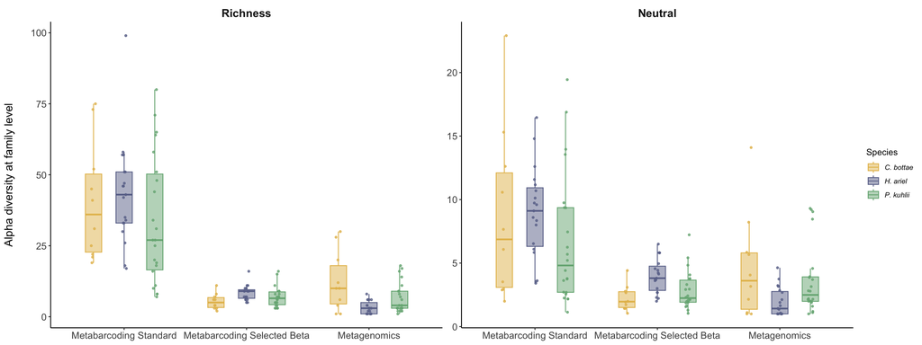

```r
alpha_div_family_data %>%
  select(-sample, -Life_stage, -Sex) %>%
  pivot_longer(
    cols = -c(method, Species),
    names_to = "metric",
    values_to = "value"
  ) %>%
  mutate(
    metric = factor(
      metric,
      levels = c("richness", "neutral"),
      labels = c("Richness", "Neutral")
    ),
    Species = factor(
      Species,
      levels = c("Eb", "Ha", "Pk"),
      labels = c("C. bottae", "H. ariel", "P. kuhlii")
      ),
    method = factor(
      method,
      levels = c("Metabarcoding_standard", "Metabarcoding_selected_beta", "Metagenomics"),
      labels = c("Metabarcoding Standard", "Metabarcoding Selected Beta", "Metagenomics")
  )) %>%
  ggplot(aes(y = value, x = method, color = Species, fill = Species)) +
  geom_boxplot(
    width = 0.4,
    alpha = 0.5,
    outlier.shape = NA,
 #   show.legend = FALSE,
    position = position_dodge(width = 0.75)
  ) +
  geom_jitter(
    position = position_jitterdodge(jitter.width = 0.1, dodge.width = 0.75),
    size = 1,
    alpha = 0.8,
    show.legend = FALSE
  ) +
  facet_wrap(~metric, scales = "free_y") +
  scale_color_manual(values=species_color,  labels = c(expression(italic("C. bottae")),
             expression(italic("H. ariel")),
             expression(italic("P. kuhlii"))))+
  scale_fill_manual(values=species_color,  labels = c(expression(italic("C. bottae")),
             expression(italic("H. ariel")),
             expression(italic("P. kuhlii")))) +
  theme_classic() +
  theme(
    strip.background = element_blank(),
    panel.grid.minor.x = element_line(size = 0.1, color = "grey"),
    axis.text.y = element_text(size = 12),
    axis.text.x = element_text(size = 12),
    axis.title.x = element_blank(),
    axis.title.y = element_text(margin = margin(t = 0, r = 20, b = 0, l = 0), size = 14),
    strip.text = element_text(size = 14, lineheight = 0.6, face = "bold")
  ) +
  labs(
#    x = "Methodological approach",
    y = "Alpha diversity at family level",
    fill = "Species"
  )
```

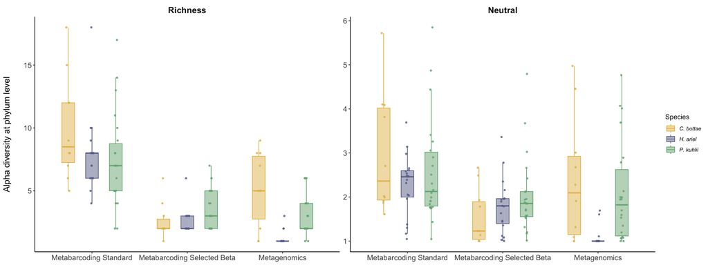

```r
alpha_div_phylum_data %>%
  select(-sample, -Life_stage, -Sex) %>%
  pivot_longer(
    cols = -c(method, Species),
    names_to = "metric",
    values_to = "value"
  ) %>%
  mutate(
    metric = factor(
      metric,
      levels = c("richness", "neutral"),
      labels = c("Richness", "Neutral")
    ),
    Species = factor(
      Species,
      levels = c("Eb", "Ha", "Pk"),
      labels = c("C. bottae", "H. ariel", "P. kuhlii")
      ),
    method = factor(
      method,
      levels = c("Metabarcoding_standard", "Metabarcoding_selected_beta", "Metagenomics"),
      labels = c("Metabarcoding Standard", "Metabarcoding Selected Beta", "Metagenomics")
  )) %>%
  ggplot(aes(y = value, x = method, color = Species, fill = Species)) +
  geom_boxplot(
    width = 0.4,
    alpha = 0.5,
    outlier.shape = NA,
 #   show.legend = FALSE,
    position = position_dodge(width = 0.75)
  ) +
  geom_jitter(
    position = position_jitterdodge(jitter.width = 0.1, dodge.width = 0.75),
    size = 1,
    alpha = 0.8,
    show.legend = FALSE
  ) +
  facet_wrap(~metric, scales = "free_y") +
  scale_color_manual(values=species_color,  labels = c(expression(italic("C. bottae")),
             expression(italic("H. ariel")),
             expression(italic("P. kuhlii"))))+
  scale_fill_manual(values=species_color,  labels = c(expression(italic("C. bottae")),
             expression(italic("H. ariel")),
             expression(italic("P. kuhlii")))) +
  theme_classic() +
  theme(
    strip.background = element_blank(),
    panel.grid.minor.x = element_line(size = 0.1, color = "grey"),
    axis.text.y = element_text(size = 12),
    axis.text.x = element_text(size = 12),
    axis.title.x = element_blank(),
    axis.title.y = element_text(margin = margin(t = 0, r = 20, b = 0, l = 0), size = 14),
    strip.text = element_text(size = 14, lineheight = 0.6, face = "bold")
  ) +
  labs(
#    x = "Methodological approach",
    y = "Alpha diversity at phylum level",
    fill = "Species"
  )
```

## 9.3 Beta diversity

### 9.3.1 At different taxonomic level

```r
beta_q0n <- family_level_agg_ampli %>%
  column_to_rownames(., "family") %>%
  hillpair(., q = 0)

beta_q1n <- family_level_agg_ampli %>%
  column_to_rownames(., "family") %>%
  hillpair(., q = 1)

beta_q0n_phylum <- phylum_level_agg_ampli %>%
  column_to_rownames(., "phylum") %>%
  hillpair(., q = 0)

beta_q1n_phylum <- phylum_level_agg_ampli %>%
  column_to_rownames(., "phylum") %>%
  hillpair(., q = 1)
```

```r
save(beta_q0n,
     beta_q1n,
     beta_q0n_phylum,
     beta_q1n_phylum,
     file = "resources/beta_tax_sele_beta.Rdata")
```

```r
load("resources/beta_tax_sele_beta.Rdata")
```

#### 9.3.1.1 Family

**Richness**

```r
adonis2(beta_q0n$S ~ Species, data = sample_metadata_amplicon %>% filter(sample %in% labels(beta_q0n$S)) %>% arrange(match(sample, labels(beta_q0n$S))),
  permutations = 999) %>%
  broom::tidy() %>%
  tt()
```

| term | df | SumOfSqs | R2 | statistic | p.value |
| --- | --- | --- | --- | --- | --- |
| Model | 2 | 1.398786 | 0.0618231 | 1.581529 | 0.022 |
| Residual | 48 | 21.226829 | 0.9381769 | NA | NA |
| Total | 50 | 22.625615 | 1.0000000 | NA | NA |

```r
pairwise.adonis(beta_q0n$S, sample_metadata_amplicon %>% filter(sample %in% labels(beta_q0n$S)) %>% arrange(match(sample, labels(beta_q0n$S))) %>% pull(Species),
  perm = 999) %>%
  tt()
```

| pairs | Df | SumsOfSqs | F.Model | R2 | p.value | p.adjusted | sig |
| --- | --- | --- | --- | --- | --- | --- | --- |
| Eb vs Ha | 1 | 1.0198664 | 2.385481 | 0.08117888 | 0.003 | 0.009 | * |
| Eb vs Pk | 1 | 0.6962595 | 1.574272 | 0.04985932 | 0.063 | 0.189 |  |
| Ha vs Pk | 1 | 0.4751619 | 1.050402 | 0.02622701 | 0.386 | 1.000 |  |

**Neutral**

```r
adonis2(beta_q1n$S ~ Species,  data = sample_metadata_amplicon %>% filter(sample %in% labels(beta_q1n$S)) %>% arrange(match(sample, labels(beta_q1n$S))), permutations = 999) %>%
  broom::tidy() %>%
  tt()
```

| term | df | SumOfSqs | R2 | statistic | p.value |
| --- | --- | --- | --- | --- | --- |
| Model | 2 | 1.350228 | 0.06036723 | 1.541893 | 0.04 |
| Residual | 48 | 21.016669 | 0.93963277 | NA | NA |
| Total | 50 | 22.366896 | 1.00000000 | NA | NA |

```r
pairwise.adonis(beta_q1n$S, sample_metadata_amplicon %>% filter(sample %in% labels(beta_q1n$S)) %>% arrange(match(sample, labels(beta_q1n$S))) %>% pull(Species), perm = 999) %>%
  tt()
```

| pairs | Df | SumsOfSqs | F.Model | R2 | p.value | p.adjusted | sig |
| --- | --- | --- | --- | --- | --- | --- | --- |
| Eb vs Ha | 1 | 1.0674286 | 2.5261102 | 0.08555513 | 0.002 | 0.006 | * |
| Eb vs Pk | 1 | 0.6882815 | 1.5814927 | 0.05007657 | 0.088 | 0.264 |  |
| Ha vs Pk | 1 | 0.3873457 | 0.8598879 | 0.02157276 | 0.587 | 1.000 |  |

#### 9.3.1.2 Phylum

**Richness**

```r
adonis2(beta_q0n_phylum$S ~ Species, data = sample_metadata_amplicon %>% filter(sample %in% labels(beta_q0n_phylum$S)) %>% arrange(match(sample, labels(beta_q0n_phylum$S))), permutations = 999) %>%
  broom::tidy() %>%
  tt()
```

| term | df | SumOfSqs | R2 | statistic | p.value |
| --- | --- | --- | --- | --- | --- |
| Model | 2 | 0.2400242 | 0.02933301 | 0.7252664 | 0.643 |
| Residual | 48 | 7.9427100 | 0.97066699 | NA | NA |
| Total | 50 | 8.1827342 | 1.00000000 | NA | NA |

**Neutral**

```r
adonis2(beta_q1n_phylum$S ~ Species,data = sample_metadata_amplicon %>%
    filter(sample %in% labels(beta_q1n_phylum$S)) %>%
    arrange(match(sample, labels(beta_q1n_phylum$S))),
  permutations = 999
) %>%
  broom::tidy() %>%
  tt()
```

| term | df | SumOfSqs | R2 | statistic | p.value |
| --- | --- | --- | --- | --- | --- |
| Model | 2 | 0.1725489 | 0.02585067 | 0.6368798 | 0.642 |
| Residual | 48 | 6.5022830 | 0.97414933 | NA | NA |
| Total | 50 | 6.6748318 | 1.00000000 | NA | NA |

### 9.3.2 Comparison between metabarcoding selected and metagenomics

```r
beta_q0n <- merged_table_family_methods %>%
  select(-H19, -H20) %>%
  column_to_rownames(., "family") %>%
  hillpair(., q = 0)

beta_q1n <- merged_table_family_methods %>%
  select(-H19) %>%
  column_to_rownames(., "family") %>%
  hillpair(., q = 1)

beta_q0n_phylum <- merged_table_phylum_methods %>%
  select(-H19, -H20) %>%
  column_to_rownames(., "phylum") %>%
  hillpair(., q = 0)

beta_q1n_phylum <- merged_table_phylum_methods %>%
  select(-H19) %>%
  column_to_rownames(., "phylum") %>%
  hillpair(., q = 1)
```

```r
save(beta_q0n,
     beta_q1n,
     beta_q0n_phylum,
     beta_q1n_phylum,
     file = "resources/beta_tax_beta.Rdata")
```

```r
load("resources/beta_tax_beta.Rdata")
methods_colors <- c("#d15aa9","#d4b9ed", "#c7c5c6")
```

#### 9.3.2.1 Family level

**Richness**

```r
m <- as.matrix(beta_q0n$S)
samples <- rownames(m)
to_remove <- grepl("_ampli$", samples) & !grepl("_ampli_Select$", samples)
m_filtered <- m[!to_remove, !to_remove]
beta_q0n_S_filtered <- as.dist(m_filtered)

samples_sel <- all_samples %>%
  mutate(sampleid = str_remove(sample, "_ampli_selec"))

samples_q0 <- samples_sel %>% filter(sample %in% labels(beta_q0n_S_filtered)) %>% arrange(match(sample, labels(beta_q0n_S_filtered)))

betadisper(beta_q0n_S_filtered, samples_q0 %>% pull(Species)) %>% permutest(.)
```

```
Permutation test for homogeneity of multivariate dispersions
Permutation: free
Number of permutations: 999

Response: Distances
          Df  Sum Sq   Mean Sq      F N.Perm Pr(>F)
Groups     2 0.02817 0.0140850 4.4954    999  0.016 *
Residuals 97 0.30392 0.0031332
---
Signif. codes:  0 '***' 0.001 '**' 0.01 '*' 0.05 '.' 0.1 ' ' 1
```

```r
adonis2(beta_q0n_S_filtered ~ Species*method, data = samples_q0, permutations = 999, strata = samples_q0$sampleid) %>%
  broom::tidy() %>%
  tt()
```

| term | df | SumOfSqs | R2 | statistic | p.value |
| --- | --- | --- | --- | --- | --- |
| Model | 5 | 5.197299 | 0.1197866 | 2.558458 | 0.001 |
| Residual | 94 | 38.190674 | 0.8802134 | NA | NA |
| Total | 99 | 43.387973 | 1.0000000 | NA | NA |

```r
adonis2(beta_q0n_S_filtered ~ Species+method, by = "margin", data = samples_q0, permutations = 999, strata = samples_q0$sampleid) %>%
  broom::tidy() %>%
  tt()
```

| term | df | SumOfSqs | R2 | statistic | p.value |
| --- | --- | --- | --- | --- | --- |
| Species | 2 | 1.898649 | 0.04375979 | 2.295924 | 0.002 |
| method | 1 | 1.772572 | 0.04085400 | 4.286935 | 0.001 |
| Residual | 96 | 39.694308 | 0.91486892 | NA | NA |
| Total | 99 | 43.387973 | 1.00000000 | NA | NA |

```r
adonis2(beta_q0n_S_filtered ~ Species*method, by = "margin", data = samples_q0, permutations = 999, strata = samples_q0$sampleid) %>%
  broom::tidy() %>%
  tt()
```

| term | df | SumOfSqs | R2 | statistic | p.value |
| --- | --- | --- | --- | --- | --- |
| Species:method | 2 | 1.503634 | 0.03465554 | 1.850472 | 0.003 |
| Residual | 94 | 38.190674 | 0.88021338 | NA | NA |
| Total | 99 | 43.387973 | 1.00000000 | NA | NA |

**Neutral**

```r
m <- as.matrix(beta_q1n$S)
samples <- rownames(m)
to_remove <- grepl("_ampli$", samples) & !grepl("_ampli_Select$", samples)
m_filtered <- m[!to_remove, !to_remove]
beta_q1n_S_filtered <- as.dist(m_filtered)

samples_q1 <- samples_sel %>% filter(sample %in% labels(beta_q1n_S_filtered)) %>% arrange(match(sample, labels(beta_q1n_S_filtered)))

betadisper(beta_q1n_S_filtered, samples_q1 %>% pull(Species)) %>% permutest(.)
```

```
Permutation test for homogeneity of multivariate dispersions
Permutation: free
Number of permutations: 999

Response: Distances
          Df  Sum Sq  Mean Sq      F N.Perm Pr(>F)
Groups     2 0.15474 0.077371 8.3185    999  0.002 **
Residuals 98 0.91151 0.009301
---
Signif. codes:  0 '***' 0.001 '**' 0.01 '*' 0.05 '.' 0.1 ' ' 1
```

```r
adonis2(beta_q1n_S_filtered ~ Species*method, data = samples_q1, permutations = 999, strata = samples_q1$sampleid) %>%
  broom::tidy() %>%
  tt()
```

| term | df | SumOfSqs | R2 | statistic | p.value |
| --- | --- | --- | --- | --- | --- |
| Model | 5 | 4.290399 | 0.09881431 | 2.083335 | 0.001 |
| Residual | 95 | 39.128401 | 0.90118569 | NA | NA |
| Total | 100 | 43.418800 | 1.00000000 | NA | NA |

```r
adonis2(beta_q1n_S_filtered ~ Species+method, by = "margin", data = samples_q1, permutations = 999, strata = samples_q1$sampleid) %>%
  broom::tidy() %>%
  tt()
```

| term | df | SumOfSqs | R2 | statistic | p.value |
| --- | --- | --- | --- | --- | --- |
| Species | 2 | 2.220116 | 0.05113259 | 2.696190 | 0.001 |
| method | 1 | 1.251519 | 0.02882436 | 3.039782 | 0.001 |
| Residual | 97 | 39.936210 | 0.91979075 | NA | NA |
| Total | 100 | 43.418800 | 1.00000000 | NA | NA |

```r
adonis2(beta_q1n_S_filtered ~ Species*method, by = "margin", data = samples_q1, permutations = 999, strata = samples_q1$sampleid) %>%
  broom::tidy() %>%
  tt()
```

| term | df | SumOfSqs | R2 | statistic | p.value |
| --- | --- | --- | --- | --- | --- |
| Species:method | 2 | 0.8078095 | 0.01860506 | 0.980642 | 0.019 |
| Residual | 95 | 39.1284008 | 0.90118569 | NA | NA |
| Total | 100 | 43.4187997 | 1.00000000 | NA | NA |

#### 9.3.2.2 Phylum level

**Richness**

```r
m <- as.matrix(beta_q0n_phylum$S)
samples <- rownames(m)
to_remove <- grepl("_ampli$", samples) & !grepl("_ampli_Select$", samples)
m_filtered <- m[!to_remove, !to_remove]
beta_q0n_phylum_S_filtered <- as.dist(m_filtered)

samples_q0 <- samples_sel %>% filter(sample %in% labels(beta_q0n_phylum_S_filtered)) %>% arrange(match(sample, labels(beta_q0n_phylum_S_filtered)))

betadisper(beta_q0n_phylum_S_filtered, samples_q0 %>% pull(Species)) %>% permutest(.)
```

```
Permutation test for homogeneity of multivariate dispersions
Permutation: free
Number of permutations: 999

Response: Distances
          Df Sum Sq Mean Sq      F N.Perm Pr(>F)
Groups     2 1.2056 0.60280 9.5619    999  0.001 ***
Residuals 97 6.1150 0.06304
---
Signif. codes:  0 '***' 0.001 '**' 0.01 '*' 0.05 '.' 0.1 ' ' 1
```

```r
adonis2(beta_q0n_phylum_S_filtered ~ Species*method, data = samples_q0, permutations = 999, strata = samples_q0$sampleid) %>%
  broom::tidy() %>%
  tt()
```

| term | df | SumOfSqs | R2 | statistic | p.value |
| --- | --- | --- | --- | --- | --- |
| Model | 5 | 3.896413 | 0.2201316 | 5.306632 | 0.001 |
| Residual | 94 | 13.803965 | 0.7798684 | NA | NA |
| Total | 99 | 17.700378 | 1.0000000 | NA | NA |

```r
adonis2(beta_q0n_phylum_S_filtered ~ Species+method, by = "margin", data = samples_q0, permutations = 999, strata = samples_q0$sampleid) %>%
  broom::tidy() %>%
  tt()
```

| term | df | SumOfSqs | R2 | statistic | p.value |
| --- | --- | --- | --- | --- | --- |
| Species | 2 | 1.9255454 | 0.10878555 | 6.054582 | 0.261 |
| method | 1 | 0.4710232 | 0.02661091 | 2.962120 | 0.018 |
| Residual | 96 | 15.2654930 | 0.86243880 | NA | NA |
| Total | 99 | 17.7003783 | 1.00000000 | NA | NA |

```r
adonis2(beta_q0n_phylum_S_filtered ~ Species*method, by = "margin", data = samples_q0, permutations = 999, strata = samples_q0$sampleid) %>%
  broom::tidy() %>%
  tt()
```

| term | df | SumOfSqs | R2 | statistic | p.value |
| --- | --- | --- | --- | --- | --- |
| Species:method | 2 | 1.461528 | 0.08257041 | 4.976236 | 0.001 |
| Residual | 94 | 13.803965 | 0.77986838 | NA | NA |
| Total | 99 | 17.700378 | 1.00000000 | NA | NA |

**Neutral**

```r
m <- as.matrix(beta_q1n_phylum$S)
samples <- rownames(m)
to_remove <- grepl("_ampli$", samples) & !grepl("_ampli_Select$", samples)
m_filtered <- m[!to_remove, !to_remove]
beta_q1n_phylum_S_filtered <- as.dist(m_filtered)

samples_q1 <- samples_sel %>% filter(sample %in% labels(beta_q1n_phylum_S_filtered)) %>% arrange(match(sample, labels(beta_q1n_phylum_S_filtered)))

betadisper(beta_q1n_phylum_S_filtered, samples_q1 %>% pull(Species)) %>% permutest(.)
```

```
Permutation test for homogeneity of multivariate dispersions
Permutation: free
Number of permutations: 999

Response: Distances
          Df Sum Sq Mean Sq      F N.Perm Pr(>F)
Groups     2 0.7182 0.35912 4.7351    999  0.013 *
Residuals 98 7.4326 0.07584
---
Signif. codes:  0 '***' 0.001 '**' 0.01 '*' 0.05 '.' 0.1 ' ' 1
```

```r
adonis2(beta_q1n_phylum_S_filtered ~ Species*method, data = samples_q1, permutations = 999, strata = samples_q1$sampleid) %>%
  broom::tidy() %>%
  tt()
```

| term | df | SumOfSqs | R2 | statistic | p.value |
| --- | --- | --- | --- | --- | --- |
| Model | 5 | 1.308865 | 0.09579321 | 2.012893 | 0.141 |
| Residual | 95 | 12.354575 | 0.90420679 | NA | NA |
| Total | 100 | 13.663439 | 1.00000000 | NA | NA |

### 9.3.3 Three methodological approaches together

#### 9.3.3.1 Family

**Richness**

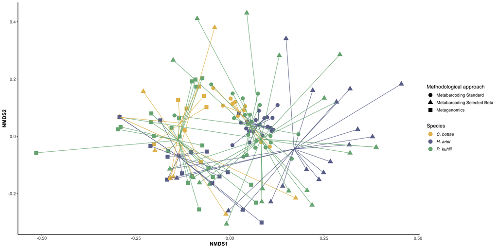

```r
beta_q0n$S %>%
  vegan::metaMDS(.,
                 trymax = 500,
                 k = 2,
                 trace = 0) %>%
  vegan::scores() %>%
  as_tibble(., rownames = "sample") %>%
  dplyr::left_join(all_samples, by = join_by(sample == sample)) %>%
  group_by(method, Species) %>%
  mutate(x_cen = mean(NMDS1, na.rm = TRUE)) %>%
  mutate(y_cen = mean(NMDS2, na.rm = TRUE)) %>%
  ungroup() %>%
  mutate(
    Species = factor(
      Species,
      levels = c("Eb", "Ha", "Pk"),
      labels = c("C. bottae", "H. ariel", "P. kuhlii")),
      method = factor(
      method,
      levels = c("Metabarcoding_standard", "Metabarcoding_selected_beta", "Metagenomics"),
      labels = c("Metabarcoding Standard", "Metabarcoding Selected Beta", "Metagenomics")
      )
  ) %>%
  ggplot(aes(x = NMDS1, y = NMDS2, color = Species, shape=method)) +
  geom_point(size = 4) +
  geom_segment(aes(x = x_cen, y = y_cen, xend = NMDS1, yend = NMDS2 ), alpha = 0.9, show.legend = FALSE) +
  scale_color_manual(values = species_color,
                     labels = c(
                       expression(italic("C. bottae")),
                       expression(italic("H. ariel")),
                       expression(italic("P. kuhlii"))
                     ))+
  theme(
    axis.title = element_text(size = 12, face = "bold"),
    axis.text = element_text(size = 10),
    panel.background = element_blank(),
    axis.line = element_line(
      size = 0.5,
      linetype = "solid",
      colour = "black"
    ),
    legend.text = element_text(size = 10),
    legend.title = element_text(size = 12),
    legend.position = "right",
    legend.box = "vertical"
  ) +
  labs(
    shape = "Methodological approach"
  )#+labs(color = "method") +geom_text_repel(aes(label = sample), size=3)
```

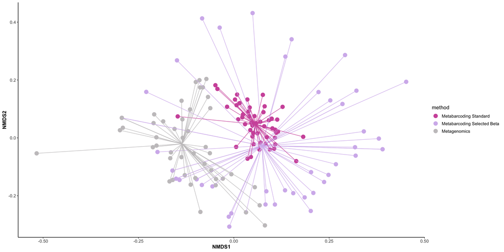

```r
beta_q0n$S %>%
  vegan::metaMDS(.,
                 trymax = 500,
                 k = 2,
                 trace = 0) %>%
  vegan::scores() %>%
  as_tibble(., rownames = "sample") %>%
  dplyr::left_join(all_samples, by = join_by(sample == sample)) %>%
  group_by(method) %>%
  mutate(x_cen = mean(NMDS1, na.rm = TRUE)) %>%
  mutate(y_cen = mean(NMDS2, na.rm = TRUE)) %>%
  ungroup() %>%
  mutate(method = factor(method,
      levels = c("Metabarcoding_standard", "Metabarcoding_selected_beta", "Metagenomics"),
      labels = c("Metabarcoding Standard", "Metabarcoding Selected Beta", "Metagenomics")
      )
  ) %>%
  ggplot(aes(x = NMDS1, y = NMDS2, color = method)) +
  geom_point(size = 4) +
  geom_segment(aes(x = x_cen, y = y_cen, xend = NMDS1, yend = NMDS2 ), alpha = 0.9, show.legend = FALSE) +
  scale_color_manual(values = methods_colors)+
  theme(
    axis.title = element_text(size = 12, face = "bold"),
    axis.text = element_text(size = 10),
    panel.background = element_blank(),
    axis.line = element_line(
      size = 0.5,
      linetype = "solid",
      colour = "black"
    ),
    legend.text = element_text(size = 10),
    legend.title = element_text(size = 12),
    legend.position = "right",
    legend.box = "vertical"
  )
```

**Neutral**

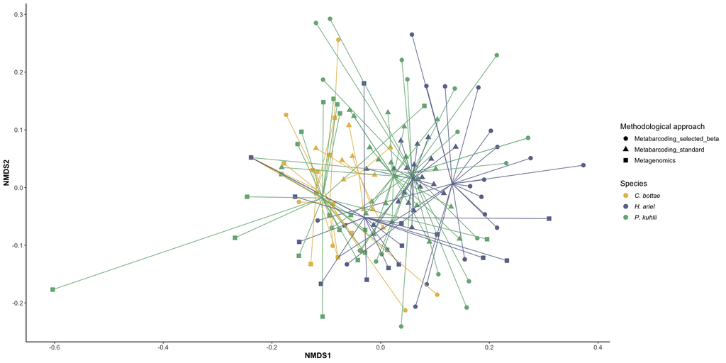

```r
beta_q1n$S %>%
  vegan::metaMDS(.,
                 trymax = 500,
                 k = 2,
                 trace = 0) %>%
  vegan::scores() %>%
  as_tibble(., rownames = "sample") %>%
  dplyr::left_join(all_samples, by = join_by(sample == sample)) %>%
  group_by(method, Species) %>%
  mutate(x_cen = mean(NMDS1, na.rm = TRUE)) %>%
  mutate(y_cen = mean(NMDS2, na.rm = TRUE)) %>%
  ungroup() %>%
  mutate(
    Species = factor(
      Species,
      levels = c("Eb", "Ha", "Pk"),
      labels = c("C. bottae", "H. ariel", "P. kuhlii"))
  ) %>%
  ggplot(aes(x = NMDS1, y = NMDS2, color = Species, shape=method)) +
  geom_point(size = 3) +
  geom_segment(aes(x = x_cen, y = y_cen, xend = NMDS1, yend = NMDS2 ), alpha = 0.9, show.legend = FALSE) +
  scale_color_manual(values = species_color,
                     labels = c(
                       expression(italic("C. bottae")),
                       expression(italic("H. ariel")),
                       expression(italic("P. kuhlii"))
                     ))+
  theme(
    axis.title = element_text(size = 12, face = "bold"),
    axis.text = element_text(size = 10),
    panel.background = element_blank(),
    axis.line = element_line(
      size = 0.5,
      linetype = "solid",
      colour = "black"
    ),
    legend.text = element_text(size = 10),
    legend.title = element_text(size = 12),
    legend.position = "right",
    legend.box = "vertical"
  ) +
  labs(shape = "Methodological approach")
```

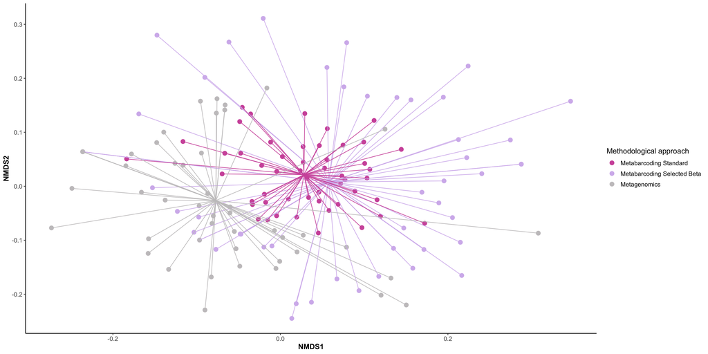

```r
beta_q1n$S %>%
  vegan::metaMDS(.,
                 trymax = 500,
                 k = 2,
                 trace = 0) %>%
  vegan::scores() %>%
  as_tibble(., rownames = "sample") %>%
  dplyr::left_join(all_samples, by = join_by(sample == sample)) %>%
  filter(sample!="P36") %>%
  group_by(method) %>%
  mutate(x_cen = mean(NMDS1, na.rm = TRUE)) %>%
  mutate(y_cen = mean(NMDS2, na.rm = TRUE)) %>%
  ungroup() %>%
    mutate(method = factor(method,
      levels = c("Metabarcoding_standard", "Metabarcoding_selected_beta", "Metagenomics"),
      labels = c("Metabarcoding Standard", "Metabarcoding Selected Beta", "Metagenomics")
      )
  ) %>%
  ggplot(aes(x = NMDS1, y = NMDS2, color = method)) +
  geom_point(size = 3) +
  geom_segment(aes(x = x_cen, y = y_cen, xend = NMDS1, yend = NMDS2 ), alpha = 0.9, show.legend = FALSE) +
  scale_color_manual(values = methods_colors)+
  theme(
    axis.title = element_text(size = 12, face = "bold"),
    axis.text = element_text(size = 10),
    panel.background = element_blank(),
    axis.line = element_line(
      size = 0.5,
      linetype = "solid",
      colour = "black"
    ),
    legend.text = element_text(size = 10),
    legend.title = element_text(size = 12),
    legend.position = "right",
    legend.box = "vertical"
  ) +
  labs(color = "Methodological approach",shape="Species")
```

#### 9.3.3.2 Phylum level

**Richness**

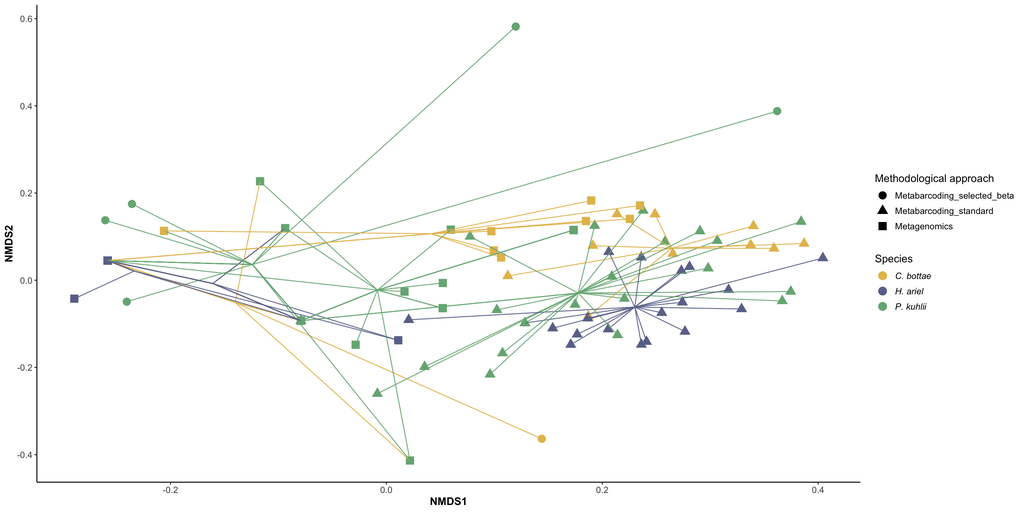

```r
beta_q0n_phylum$S %>%
  vegan::metaMDS(.,
                 trymax = 500,
                 k = 2,
                 trace = 0) %>%
  vegan::scores() %>%
  as_tibble(., rownames = "sample") %>%
  dplyr::left_join(all_samples, by = join_by(sample == sample)) %>%
  group_by(method, Species) %>%
  mutate(x_cen = mean(NMDS1, na.rm = TRUE)) %>%
  mutate(y_cen = mean(NMDS2, na.rm = TRUE)) %>%
  ungroup() %>%
  mutate(
    Species = factor(
      Species,
      levels = c("Eb", "Ha", "Pk"),
      labels = c("C. bottae", "H. ariel", "P. kuhlii"))
  ) %>%
  ggplot(aes(x = NMDS1, y = NMDS2, color = Species, shape=method)) +
  geom_point(size = 4) +
  geom_segment(aes(x = x_cen, y = y_cen, xend = NMDS1, yend = NMDS2 ), alpha = 0.9, show.legend = FALSE) +
  scale_color_manual(values = species_color,
                     labels = c(
                       expression(italic("C. bottae")),
                       expression(italic("H. ariel")),
                       expression(italic("P. kuhlii"))
                     ))+
  theme(
    axis.title = element_text(size = 12, face = "bold"),
    axis.text = element_text(size = 10),
    panel.background = element_blank(),
    axis.line = element_line(
      size = 0.5,
      linetype = "solid",
      colour = "black"
    ),
    legend.text = element_text(size = 10),
    legend.title = element_text(size = 12),
    legend.position = "right",
    legend.box = "vertical"
  ) +
  labs(
    shape = "Methodological approach"
  )
```

**Neutral**

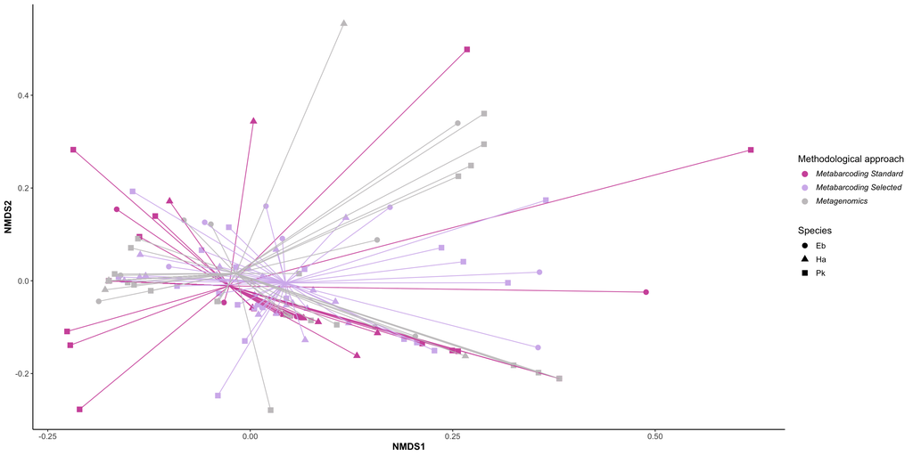

```r
beta_q1n_phylum$S %>%
  vegan::metaMDS(.,
                 trymax = 500,
                 k = 2,
                 trace = 0) %>%
  vegan::scores() %>%
  as_tibble(., rownames = "sample") %>%
  dplyr::left_join(all_samples, by = join_by(sample == sample)) %>%
  group_by(method) %>%
  mutate(x_cen = mean(NMDS1, na.rm = TRUE)) %>%
  mutate(y_cen = mean(NMDS2, na.rm = TRUE)) %>%
  ungroup() %>%
  ggplot(aes(x = NMDS1, y = NMDS2, color = method, shape= Species)) +
  geom_point(size = 3) +
  geom_segment(aes(x = x_cen, y = y_cen, xend = NMDS1, yend = NMDS2 ), alpha = 0.9, show.legend = FALSE) +
  scale_color_manual(values = methods_colors,
                     labels = c(
                       expression(italic("Metabarcoding Standard")),
                       expression(italic("Metabarcoding Selected")),
                       expression(italic("Metagenomics"))
                     ))+
  theme(
    axis.title = element_text(size = 12, face = "bold"),
    axis.text = element_text(size = 10),
    panel.background = element_blank(),
    axis.line = element_line(
      size = 0.5,
      linetype = "solid",
      colour = "black"
    ),
    legend.text = element_text(size = 10),
    legend.title = element_text(size = 12),
    legend.position = "right",
    legend.box = "vertical"
  ) +
  labs(color = "Methodological approach",shape="Species")
```

## 9.4 Differential abundance

### 9.4.1 Metabarcoding selected

```r
load("resources/amplicon/selected_filtering_beta.Rdata")
```

```r
phylo_samples <- sample_metadata_amplicon %>%
  column_to_rownames("sample") %>%
  sample_data()

phylo_genome <- genome_counts_filt_amplicon %>%
  select(one_of(c("genome", rownames(phylo_samples)))) %>%
  column_to_rownames("genome") %>%
  otu_table(., taxa_are_rows = TRUE)

phylo_taxonomy <- genome_metadata_amplicon %>%
  filter(genome %in% rownames(phylo_genome)) %>%
  column_to_rownames("genome") %>%
  dplyr::select(domain,phylum,class,order,family,genus,species) %>%
  as.matrix() %>%
  tax_table()

physeq_genome_metab_sel <- phyloseq(phylo_genome, phylo_samples, phylo_taxonomy)
```

```r
ancom_rand_output_phylum_metab_sel_beta = ancombc2(
  data = physeq_genome_metab_sel,
  assay_name = "counts",
  tax_level = "phylum",
  fix_formula = "Species",
  p_adj_method = "holm",
  pseudo_sens = TRUE,
  prv_cut = 0,
  lib_cut = 0,
  s0_perc = 0.05,
  group = "Species",
  struc_zero = TRUE,
  neg_lb = FALSE,
  alpha = 0.05,
  n_cl = 2,
  verbose = TRUE,
  global = TRUE,
  pairwise = TRUE,
  dunnet = FALSE,
  trend = FALSE,
  iter_control = list(
    tol = 1e-5,
    max_iter = 20,
    verbose = FALSE
  ),
  em_control = list(tol = 1e-5, max_iter = 100),
  mdfdr_control = list(fwer_ctrl_method = "holm", B = 100),
  trend_control = NULL
)
```

#### 9.4.1.1 Structural zeros

*Total number of structural zeros*

```r
# Extract structural zeros
structural_zeros <- ancom_rand_output_phylum_metab_sel_beta$zero_ind

# Convert to a data frame for better readability
structural_zeros_df <- as.data.frame(structural_zeros) %>%
  column_to_rownames(., "taxon")

structural_zero_taxa <- rownames(structural_zeros_df)[apply(structural_zeros_df, 1, any)]

# Identify in which groups each taxon is a structural zero
structural_zero_groups <- structural_zeros_df[structural_zero_taxa, , drop = FALSE] %>%
  rename("Eb"=1) %>%
  rename("Ha"=2) %>%
  rename("Pk"=3)

# Total number of structural zeros
nrow(structural_zero_groups)
```

```
[1] 5
```

#### 9.4.1.2 Enriched data

```r
res_pair_phylum <- ancom_rand_output_phylum_metab_sel_beta$res_pair
# Get log-fold change and q-value columns
lfc_cols <- grep("^lfc_", colnames(res_pair_phylum), value = TRUE)
q_cols   <- gsub("^lfc_", "q_", lfc_cols)

# Build long table by pairing lfc and q for each contrast
plot_data_phylum <- lfc_cols %>%
  setNames(nm = .) %>%
  purrr::imap_dfr(function(lfc_col, name) {
    q_col <- gsub("^lfc_", "q_", lfc_col)

    res_pair_phylum %>%
      select(taxon, !!lfc_col, !!q_col) %>%
      rename(
        lfc = !!lfc_col,
        q   = !!q_col
      ) %>%
      mutate(contrast_key = name)
  }) %>%
  filter(!is.na(lfc), !is.na(q), q < 0.05) %>%
  mutate(
    # Manually re-label contrasts for clarity
    contrast = case_when(
      contrast_key == "lfc_SpeciesHa" ~ "H. ariel vs C. bottae",
      contrast_key == "lfc_SpeciesPk" ~ "P. kuhlii vs C. bottae",
      contrast_key == "lfc_SpeciesPk_SpeciesHa" ~ "P. kuhlii vs H. ariel",
      TRUE ~ contrast_key
    ),
    direction = ifelse(lfc > 0, paste("Enriched in", sub(" vs.*", "", contrast)),
                             paste("Enriched in", sub(".*vs ", "", contrast)))
  )
plot_data_phylum %>% select(-contrast_key)
```

```
           taxon       lfc            q               contrast             direction
1 Fusobacteriota -2.999425 0.0069606310  H. ariel vs C. bottae Enriched in C. bottae
2   Bacteroidota  3.662399 0.0006033366  H. ariel vs C. bottae  Enriched in H. ariel
3   Bacteroidota  2.205370 0.0161298287 P. kuhlii vs C. bottae Enriched in P. kuhlii
4 Fusobacteriota  2.375825 0.0287267228  P. kuhlii vs H. ariel Enriched in P. kuhlii
```

### 9.4.2 Differences with metagenomics at phylum level across species

```r
load("resources/amplicon/selected_filtering_beta.Rdata")

sample_metadata_amplicon <- sample_metadata_amplicon[c(1,9,10,13)] %>%
  mutate(sample = paste0(sample, "_ampli")) %>%
  mutate(method="Metabarcoding")

genome_metadata_ampli <- genome_metadata_amplicon %>%
  mutate(
    class  = if_else(is.na(class), paste0(phylum, "_Unclassified"), class),
    order  = if_else(is.na(order),
                     if_else(str_detect(class, "Unclassified"), class, paste0(class, "_Unclassified")),
                     order),
    family = if_else(is.na(family),
                     if_else(str_detect(order, "Unclassified"), order, paste0(order, "_Unclassified")),
                     family),
    genus  = if_else(is.na(genus),
                     if_else(str_detect(family, "Unclassified"), family, paste0(family, "_Unclassified")),
                     genus)
  )

genome_tax_ampli <- genome_counts_filt_amplicon %>%
  column_to_rownames(., "genome")%>%
  rename_with(~ paste0(., "_ampli")) %>%
  rownames_to_column(., "genome")%>%
  left_join(genome_metadata_ampli, by = "genome")

family_level_agg_ampli <- genome_tax_ampli %>%
  select(-genome) %>%
  group_by(phylum, class, family) %>%
  summarise(across(where(is.numeric), \(x) sum(x, na.rm = TRUE)), .groups = "drop")%>%
    as.data.frame() %>%
  select(-c(phylum,class))

phylum_level_agg_ampli <- genome_tax_ampli %>%
  select(-genome) %>%
  group_by(phylum) %>%
  summarise(across(where(is.numeric), \(x) sum(x, na.rm = TRUE)), .groups = "drop")%>%
    as.data.frame()
```

```r
load("resources/metagenomics/data_filtered.Rdata")

genome_metadata <- genome_metadata %>%
  mutate(
    class  = if_else(str_trim(class) == "", paste0(phylum, "_Unclassified"), class),
    order  = if_else(str_trim(order) == "",
                     if_else(str_detect(class, "Unclassified"), class, paste0(class, "_Unclassified")),
                     order),
    family = if_else(str_trim(family) == "",
                     if_else(str_detect(order, "Unclassified"), order, paste0(order, "_Unclassified")),
                     family),
    genus  = if_else(str_trim(genus) == "",
                     if_else(str_detect(family, "Unclassified"), family, paste0(family, "_Unclassified")),
                     genus)
  )

genome_tax <- genome_counts_filt %>%
  left_join(genome_metadata[c(1,3,4,6)], by = "genome")

# Aggregate counts at the Family level
family_level_agg <- genome_tax %>%
  select(-genome) %>%
  group_by(phylum, class, family) %>%
  summarise(across(where(is.numeric), \(x) sum(x, na.rm = TRUE)), .groups = "drop")%>%
  as.data.frame() %>%
  select(-c(phylum,class))

# Aggregate counts at the Phylum level
phylum_level_agg <- genome_tax %>%
  select(-genome) %>%
  group_by(phylum) %>%
  summarise(across(where(is.numeric), \(x) sum(x, na.rm = TRUE)), .groups = "drop")%>%
  as.data.frame()
```

```r
merged_table <- full_join(family_level_agg_ampli,family_level_agg,
          by = c("family"))%>%
  mutate(across(where(is.numeric), ~replace_na(., 0)))

merged_table_phylum <- full_join(phylum_level_agg_ampli,phylum_level_agg,
          by = c("phylum"))%>%
  mutate(across(where(is.numeric), ~replace_na(., 0)))


sample_shot <- sample_metadata %>%
  select(-c(Habitat,Longitude, Latitude, Region))%>%
  mutate(method="Metagenomics")

all_samples <- rbind(sample_shot, sample_metadata_amplicon)

samples_sel <- all_samples %>%
  mutate(sampleid = str_remove(sample, "_ampli"))

phylo_genome <- merged_table_phylum %>%
  column_to_rownames("phylum") %>%
  otu_table(., taxa_are_rows = TRUE)

phylo_samples <- samples_sel %>%
  mutate(individual=sample) %>%
  column_to_rownames("sample") %>%
  sample_data()

merged_physeq_phylum <- phyloseq(phylo_genome, phylo_samples)
```

```r
ancom_rand_output_struc_approach_rand_beta = ancombc2(data = merged_physeq_phylum,
                  assay_name = "counts",
                  tax_level = NULL,
                  fix_formula = "method",
 #                 rand_formula = "(1|sampleid)",
                  p_adj_method = "holm",
                  pseudo_sens = TRUE,
                  prv_cut =0,
                  lib_cut = 0,
                  s0_perc = 0.05,
                  group = "method",
                  struc_zero = TRUE,
                  neg_lb = FALSE,
                  alpha = 0.05,
                  n_cl = 2,
                  verbose = TRUE,
                  global = FALSE,
                  pairwise = FALSE,
                  dunnet = FALSE,
                  trend = FALSE,
                  iter_control = list(tol = 1e-5, max_iter = 20, verbose = FALSE),
                  em_control = list(tol = 1e-5, max_iter = 100),
  #               lme_control = lme4::lmerControl(),
                  mdfdr_control = list(fwer_ctrl_method = "holm", B = 100),
                  trend_control = NULL)
```

*Enriched phyla*

```r
ancom_rand_output_struc_approach_rand_beta$res %>%
  filter(q_methodMetagenomics < 0.05) %>%
  tt()
```

| taxon | lfc_(Intercept) | lfc_methodMetagenomics | se_(Intercept) | se_methodMetagenomics | W_(Intercept) | W_methodMetagenomics | p_(Intercept) | p_methodMetagenomics | q_(Intercept) | q_methodMetagenomics | diff_(Intercept) | diff_methodMetagenomics | passed_ss_(Intercept) | passed_ss_methodMetagenomics |
| --- | --- | --- | --- | --- | --- | --- | --- | --- | --- | --- | --- | --- | --- | --- |
| Bacillota | 0.4631885 | -0.9504081 | NaN | 0.2917864 | NaN | -3.257205 | 1 | 1.699690e-03 | 1 | 8.498452e-03 | FALSE | TRUE | FALSE | TRUE |
| Cyanobacteriota | -1.0681707 | 1.6064923 | NaN | 0.1443157 | NaN | 11.131795 | 1 | 1.020098e-04 | 1 | 7.140686e-04 | FALSE | TRUE | FALSE | TRUE |
| Desulfobacterota | -0.2977490 | 0.7242459 | NaN | 0.1908770 | NaN | 3.794306 | 1 | 1.328135e-03 | 1 | 7.968809e-03 | FALSE | TRUE | FALSE | TRUE |
| Pseudomonadota | 1.5499865 | -1.9428009 | NaN | 0.3049521 | NaN | -6.370840 | 1 | 6.494332e-09 | 1 | 5.195466e-08 | FALSE | TRUE | FALSE | TRUE |

### 9.4.3 Differences with metagenomics at phylum level within each species

#### 9.4.3.1 Cnephaeus

```r
physeq_eb <- subset_samples(merged_physeq_phylum, Species == "Eb")
physeq_eb <- prune_taxa(taxa_sums(physeq_eb)>0, physeq_eb)
```

```r
ancom_rand_output_struc_eb = ancombc2(data = physeq_eb,
                  assay_name = "counts",
                  tax_level = NULL,
                  fix_formula = "method",
                  p_adj_method = "holm",
                  pseudo_sens = TRUE,
                  prv_cut =0,
                  lib_cut = 0,
                  s0_perc = 0.05,
                  group = "method",
                  struc_zero = TRUE,
                  neg_lb = FALSE,
                  alpha = 0.05,
                  n_cl = 2,
                  verbose = TRUE,
                  global = FALSE,
                  pairwise = FALSE,
                  dunnet = FALSE,
                  trend = FALSE,
                  iter_control = list(tol = 1e-5, max_iter = 20, verbose = FALSE),
                  em_control = list(tol = 1e-5, max_iter = 100),
                  mdfdr_control = list(fwer_ctrl_method = "holm", B = 100),
                  trend_control = NULL)
```

*Total structural zeros*

```r
structural_zeros <- ancom_rand_output_struc_eb$zero_ind

structural_zeros_df <- as.data.frame(structural_zeros) %>%
  column_to_rownames(., "taxon")

structural_zero_taxa <- rownames(structural_zeros_df)[apply(structural_zeros_df, 1, any)]

structural_zero_groups <- structural_zeros_df[structural_zero_taxa, , drop = FALSE] %>%
  rename("amplicon"=1) %>%
  rename("metagenomics"=2)

nrow(structural_zero_groups)
```

```
[1] 6
```

*Structural zeros in amplicon*

```r
structural_zero_groups %>%
  filter(amplicon==TRUE) %>%
  nrow()
```

```
[1] 5
```

```r
structural_zero_groups %>%
  filter(amplicon==TRUE) %>%
  rownames_to_column(., "phylum") %>%
  left_join(., data.frame(physeq_eb@tax_table) %>% rownames_to_column(., "phylum"), by="phylum") %>%
  select(phylum) %>%
  pull()
```

```
[1] "Campylobacterota" "Deferribacterota" "Elusimicrobiota"  "Planctomycetota"  "Synergistota"
```

*Structural zeros in metagenomics*

```r
structural_zero_groups %>%
  filter(metagenomics==TRUE) %>%
  rownames_to_column(., "phylum") %>%
  left_join(., data.frame(physeq_eb@tax_table) %>% rownames_to_column(., "phylum"), by="phylum") %>%
  select(phylum) %>%
  pull()
```

```
[1] "Rs-K70 termite group"
```

*Enriched phyla*

```r
ancom_rand_output_struc_eb$res %>%
  filter(q_methodMetagenomics<0.05) %>%
  tt()
```

| taxon | lfc_(Intercept) | lfc_methodMetagenomics | se_(Intercept) | se_methodMetagenomics | W_(Intercept) | W_methodMetagenomics | p_(Intercept) | p_methodMetagenomics | q_(Intercept) | q_methodMetagenomics | diff_(Intercept) | diff_methodMetagenomics | passed_ss_(Intercept) | passed_ss_methodMetagenomics |
| --- | --- | --- | --- | --- | --- | --- | --- | --- | --- | --- | --- | --- | --- | --- |
| Bacteroidota | -1.426982 | 2.069855 | 0.1952675 | 0.5456508 | -7.307833 | 3.793369 | 3.349849e-04 | 0.009037660 | 0.0013399395 | 0.03615064 | TRUE | TRUE | FALSE | TRUE |
| Desulfobacterota | -1.587317 | 2.498657 | 0.1923669 | 0.5875411 | -8.251509 | 4.252735 | 7.476295e-05 | 0.003780339 | 0.0003738147 | 0.01890169 | TRUE | TRUE | TRUE | TRUE |

#### 9.4.3.2 Pipistrellus

```r
physeq_pk <- subset_samples(merged_physeq_phylum, Species == "Pk")
physeq_pk <- prune_taxa(taxa_sums(physeq_pk)>0, physeq_pk)
```

```r
ancom_rand_output_struc_pk = ancombc2(data = physeq_pk,
                  assay_name = "counts",
                  tax_level = NULL,
                  fix_formula = "method",
                  p_adj_method = "holm",
                  pseudo_sens = TRUE,
                  prv_cut =0,
                  lib_cut = 0,
                  s0_perc = 0.05,
                  group = "method",
                  struc_zero = TRUE,
                  neg_lb = FALSE,
                  alpha = 0.05,
                  n_cl = 2,
                  verbose = TRUE,
                  global = FALSE,
                  pairwise = FALSE,
                  dunnet = FALSE,
                  trend = FALSE,
                  iter_control = list(tol = 1e-5, max_iter = 20, verbose = FALSE),
                  em_control = list(tol = 1e-5, max_iter = 100),
                  mdfdr_control = list(fwer_ctrl_method = "holm", B = 100),
                  trend_control = NULL)
```

*Total structural zeros*

```r
structural_zeros <- ancom_rand_output_struc_pk$zero_ind

structural_zeros_df <- as.data.frame(structural_zeros) %>%
  column_to_rownames(., "taxon")

structural_zero_taxa <- rownames(structural_zeros_df)[apply(structural_zeros_df, 1, any)]

structural_zero_groups <- structural_zeros_df[structural_zero_taxa, , drop = FALSE] %>%
  rename("amplicon"=1) %>%
  rename("metagenomics"=2)

nrow(structural_zero_groups)
```

```
[1] 4
```

*Structural zeros in amplicon*

```r
structural_zero_groups %>%
  filter(amplicon==TRUE) %>%
  nrow()
```

```
[1] 1
```

```r
structural_zero_groups %>%
  filter(amplicon==TRUE) %>%
  rownames_to_column(., "phylum") %>%
  left_join(., data.frame(physeq_eb@tax_table) %>% rownames_to_column(., "phylum"), by="phylum") %>%
  select(phylum) %>%
  pull()
```

```
[1] "Synergistota"
```

*Structural zeros in metagenomics*

```r
structural_zero_groups %>%
  filter(metagenomics==TRUE) %>%
  rownames_to_column(., "phylum") %>%
  left_join(., data.frame(physeq_eb@tax_table) %>% rownames_to_column(., "phylum"), by="phylum") %>%
  select(phylum) %>%
  pull()
```

```
[1] "Halobacterota"        "Rs-K70 termite group" "Verrucomicrobiota"
```

*Enriched phyla*

```r
ancom_rand_output_struc_pk$res %>%
  filter(q_methodMetagenomics<0.05) %>%
  tt()
```

| taxon | lfc_(Intercept) | lfc_methodMetagenomics | se_(Intercept) | se_methodMetagenomics | W_(Intercept) | W_methodMetagenomics | p_(Intercept) | p_methodMetagenomics | q_(Intercept) | q_methodMetagenomics | diff_(Intercept) | diff_methodMetagenomics | passed_ss_(Intercept) | passed_ss_methodMetagenomics |
| --- | --- | --- | --- | --- | --- | --- | --- | --- | --- | --- | --- | --- | --- | --- |
| Bacillota | 1.354895 | -1.500774 | 0.3216512 | 0.4736496 | 4.212310 | -3.168533 | 1.553444e-04 | 0.0030692348 | 0.0009320667 | 0.018415409 | TRUE | TRUE | FALSE | FALSE |
| Pseudomonadota | 1.673483 | -2.163873 | 0.3477039 | 0.5625639 | 4.812954 | -3.846448 | 2.144767e-05 | 0.0004209894 | 0.0001501337 | 0.002946926 | TRUE | TRUE | TRUE | TRUE |

#### 9.4.3.3 Hypsugo

```r
physeq_ha <- subset_samples(merged_physeq_phylum, Species == "Ha")
physeq_ha <- prune_taxa(taxa_sums(physeq_ha)>0, physeq_ha)
```

```r
ancom_rand_output_struc_ha = ancombc2(data = physeq_ha,
                  assay_name = "counts",
                  tax_level = NULL,
                  fix_formula = "method",
                  p_adj_method = "holm",
                  pseudo_sens = TRUE,
                  prv_cut =0,
                  lib_cut = 0,
                  s0_perc = 0.05,
                  group = "method",
                  struc_zero = TRUE,
                  neg_lb = FALSE,
                  alpha = 0.05,
                  n_cl = 2,
                  verbose = TRUE,
                  global = FALSE,
                  pairwise = FALSE,
                  dunnet = FALSE,
                  trend = FALSE,
                  iter_control = list(tol = 1e-5, max_iter = 20, verbose = FALSE),
                  em_control = list(tol = 1e-5, max_iter = 100),
                  mdfdr_control = list(fwer_ctrl_method = "holm", B = 100),
                  trend_control = NULL)
```

*Total structural zeros*

```r
structural_zeros <- ancom_rand_output_struc_ha$zero_ind

structural_zeros_df <- as.data.frame(structural_zeros) %>%
  column_to_rownames(., "taxon")

structural_zero_taxa <- rownames(structural_zeros_df)[apply(structural_zeros_df, 1, any)]

structural_zero_groups <- structural_zeros_df[structural_zero_taxa, , drop = FALSE] %>%
  rename("amplicon"=1) %>%
  rename("metagenomics"=2)

nrow(structural_zero_groups)
```

```
[1] 5
```

*Structural zeros in amplicon*

```r
structural_zero_groups %>%
  filter(amplicon==TRUE) %>%
  nrow()
```

```
[1] 1
```

```r
structural_zero_groups %>%
  filter(amplicon==TRUE) %>%
  rownames_to_column(., "phylum") %>%
  left_join(., data.frame(physeq_eb@tax_table) %>% rownames_to_column(., "phylum"), by="phylum") %>%
  select(phylum) %>%
  pull()
```

```
[1] "Spirochaetota"
```

*Structural zeros in metagenomics*

```r
structural_zero_groups %>%
  filter(metagenomics==TRUE) %>%
  rownames_to_column(., "phylum") %>%
  left_join(., data.frame(physeq_eb@tax_table) %>% rownames_to_column(., "phylum"), by="phylum") %>%
  select(phylum) %>%
  pull()
```

```
[1] "Cyanobacteriota"      "Desulfobacterota"     "Fusobacteriota"       "Rs-K70 termite group"
```

*Enriched phyla*

```r
ancom_rand_output_struc_ha$res %>%
  filter(q_methodMetagenomics<0.05) %>%
  tt()
```

| taxon | lfc_(Intercept) | lfc_methodMetagenomics | se_(Intercept) | se_methodMetagenomics | W_(Intercept) | W_methodMetagenomics | p_(Intercept) | p_methodMetagenomics | q_(Intercept) | q_methodMetagenomics | diff_(Intercept) | diff_methodMetagenomics | passed_ss_(Intercept) | passed_ss_methodMetagenomics |
| --- | --- | --- | --- | --- | --- | --- | --- | --- | --- | --- | --- | --- | --- | --- |
| Bacillota | 0.06866148 | 2.172955 | NaN | 0.3836565 | NaN | 5.663804 | 1 | 1.845838e-05 | 1 | 7.383351e-05 | FALSE | TRUE | FALSE | TRUE |